# Problem Set 1, due April 13th at 3:30pm

(in other words, it is due at noon, or one minute after 11:59am).

### Before You Start

Make sure to at least take a basic tutorial in the IPython notebook, otherwise you'll be totally lost. For this problem set, you should download INFX574-PS1.ipynb and the flights.zip dataset from Canvas. Create a local copy of the notebook and rename it LASTNAME_FIRSTNAME-PS1.ipynb. Then edit your renamed file directly in your browser by typing:

```
ipython notebook <name_of_downloaded_file>
```

You should also make sure the following libraries load correctly (click on the box below and hit Ctrl-Enter)

```python
#IPython is what you are using now to run the notebook
import IPython
#print ("IPython version:      %6.6s (need at least 1.0)" % IPython.__version_)
# Numpy is a library for working with Arrays
import numpy as np
#print ("Numpy version:        %6.6s (need at least 1.7.1)" % np.__version__)

# SciPy implements many different numerical algorithms
import scipy as sp
#print ("SciPy version:        %6.6s (need at least 0.12.0)" % sp.__version__)

# Pandas makes working with data tables easier
import pandas as pd
#print ("Pandas version:       %6.6s (need at least 0.11.0)" % pd.__version__)

# Module for plotting
import matplotlib
#print ("Mapltolib version:    %6.6s (need at least 1.2.1)" % matplotlib.__version__)

# SciKit Learn implements several Machine Learning algorithms
import sklearn
#print ("Scikit-Learn version: %6.6s (need at least 0.13.1)" % sklearn.__version__)
```

## About the Problem Set:

This is the same problem set used by Emma Spiro in INFX573. The only difference is that instead of doing the problem set in R, you will use Python and the IPython notebook.

## Instructions:

In this problem set you will perform a basic exploratory analysis on an example dataset, bringing to bear all of your new skills in data manipulation and visualization. You will be required to submit well commented python code, documenting all code used in this problem set, along with a write up answering all questions below. Use figures as appropriate to support your answers, and when required by the problem. This data set uses the NYCFlights13 dataset. You can download the dataset from canvas.

```python
import pandas as pd
import numpy as np
import matplotlib.pyplot as plt
```

```python
flights_df= pd.read_csv('flights.csv')
flights_df
```

|  | Unnamed: 0 | year | month | day | dep_time | dep_delay | arr_time | arr_delay | carrier | tailnum | flight | origin | dest | air_time | distance | hour | minute |
| --- | --- | --- | --- | --- | --- | --- | --- | --- | --- | --- | --- | --- | --- | --- | --- | --- | --- |
| 0 | 1 | 2013 | 1 | 1 | 517.0 | 2.0 | 830.0 | 11.0 | UA | N14228 | 1545 | EWR | IAH | 227.0 | 1400 | 5.0 | 17.0 |
| 1 | 2 | 2013 | 1 | 1 | 533.0 | 4.0 | 850.0 | 20.0 | UA | N24211 | 1714 | LGA | IAH | 227.0 | 1416 | 5.0 | 33.0 |
| 2 | 3 | 2013 | 1 | 1 | 542.0 | 2.0 | 923.0 | 33.0 | AA | N619AA | 1141 | JFK | MIA | 160.0 | 1089 | 5.0 | 42.0 |
| 3 | 4 | 2013 | 1 | 1 | 544.0 | -1.0 | 1004.0 | -18.0 | B6 | N804JB | 725 | JFK | BQN | 183.0 | 1576 | 5.0 | 44.0 |
| 4 | 5 | 2013 | 1 | 1 | 554.0 | -6.0 | 812.0 | -25.0 | DL | N668DN | 461 | LGA | ATL | 116.0 | 762 | 5.0 | 54.0 |
| 5 | 6 | 2013 | 1 | 1 | 554.0 | -4.0 | 740.0 | 12.0 | UA | N39463 | 1696 | EWR | ORD | 150.0 | 719 | 5.0 | 54.0 |
| 6 | 7 | 2013 | 1 | 1 | 555.0 | -5.0 | 913.0 | 19.0 | B6 | N516JB | 507 | EWR | FLL | 158.0 | 1065 | 5.0 | 55.0 |
| 7 | 8 | 2013 | 1 | 1 | 557.0 | -3.0 | 709.0 | -14.0 | EV | N829AS | 5708 | LGA | IAD | 53.0 | 229 | 5.0 | 57.0 |
| 8 | 9 | 2013 | 1 | 1 | 557.0 | -3.0 | 838.0 | -8.0 | B6 | N593JB | 79 | JFK | MCO | 140.0 | 944 | 5.0 | 57.0 |
| 9 | 10 | 2013 | 1 | 1 | 558.0 | -2.0 | 753.0 | 8.0 | AA | N3ALAA | 301 | LGA | ORD | 138.0 | 733 | 5.0 | 58.0 |
| 10 | 11 | 2013 | 1 | 1 | 558.0 | -2.0 | 849.0 | -2.0 | B6 | N793JB | 49 | JFK | PBI | 149.0 | 1028 | 5.0 | 58.0 |
| 11 | 12 | 2013 | 1 | 1 | 558.0 | -2.0 | 853.0 | -3.0 | B6 | N657JB | 71 | JFK | TPA | 158.0 | 1005 | 5.0 | 58.0 |
| 12 | 13 | 2013 | 1 | 1 | 558.0 | -2.0 | 924.0 | 7.0 | UA | N29129 | 194 | JFK | LAX | 345.0 | 2475 | 5.0 | 58.0 |
| 13 | 14 | 2013 | 1 | 1 | 558.0 | -2.0 | 923.0 | -14.0 | UA | N53441 | 1124 | EWR | SFO | 361.0 | 2565 | 5.0 | 58.0 |
| 14 | 15 | 2013 | 1 | 1 | 559.0 | -1.0 | 941.0 | 31.0 | AA | N3DUAA | 707 | LGA | DFW | 257.0 | 1389 | 5.0 | 59.0 |
| 15 | 16 | 2013 | 1 | 1 | 559.0 | 0.0 | 702.0 | -4.0 | B6 | N708JB | 1806 | JFK | BOS | 44.0 | 187 | 5.0 | 59.0 |
| 16 | 17 | 2013 | 1 | 1 | 559.0 | -1.0 | 854.0 | -8.0 | UA | N76515 | 1187 | EWR | LAS | 337.0 | 2227 | 5.0 | 59.0 |
| 17 | 18 | 2013 | 1 | 1 | 600.0 | 0.0 | 851.0 | -7.0 | B6 | N595JB | 371 | LGA | FLL | 152.0 | 1076 | 6.0 | 0.0 |
| 18 | 19 | 2013 | 1 | 1 | 600.0 | 0.0 | 837.0 | 12.0 | MQ | N542MQ | 4650 | LGA | ATL | 134.0 | 762 | 6.0 | 0.0 |
| 19 | 20 | 2013 | 1 | 1 | 601.0 | 1.0 | 844.0 | -6.0 | B6 | N644JB | 343 | EWR | PBI | 147.0 | 1023 | 6.0 | 1.0 |
| 20 | 21 | 2013 | 1 | 1 | 602.0 | -8.0 | 812.0 | -8.0 | DL | N971DL | 1919 | LGA | MSP | 170.0 | 1020 | 6.0 | 2.0 |
| 21 | 22 | 2013 | 1 | 1 | 602.0 | -3.0 | 821.0 | 16.0 | MQ | N730MQ | 4401 | LGA | DTW | 105.0 | 502 | 6.0 | 2.0 |
| 22 | 23 | 2013 | 1 | 1 | 606.0 | -4.0 | 858.0 | -12.0 | AA | N633AA | 1895 | EWR | MIA | 152.0 | 1085 | 6.0 | 6.0 |
| 23 | 24 | 2013 | 1 | 1 | 606.0 | -4.0 | 837.0 | -8.0 | DL | N3739P | 1743 | JFK | ATL | 128.0 | 760 | 6.0 | 6.0 |
| 24 | 25 | 2013 | 1 | 1 | 607.0 | 0.0 | 858.0 | -17.0 | UA | N53442 | 1077 | EWR | MIA | 157.0 | 1085 | 6.0 | 7.0 |
| 25 | 26 | 2013 | 1 | 1 | 608.0 | 8.0 | 807.0 | 32.0 | MQ | N9EAMQ | 3768 | EWR | ORD | 139.0 | 719 | 6.0 | 8.0 |
| 26 | 27 | 2013 | 1 | 1 | 611.0 | 11.0 | 945.0 | 14.0 | UA | N532UA | 303 | JFK | SFO | 366.0 | 2586 | 6.0 | 11.0 |
| 27 | 28 | 2013 | 1 | 1 | 613.0 | 3.0 | 925.0 | 4.0 | B6 | N635JB | 135 | JFK | RSW | 175.0 | 1074 | 6.0 | 13.0 |
| 28 | 29 | 2013 | 1 | 1 | 615.0 | 0.0 | 1039.0 | -21.0 | B6 | N794JB | 709 | JFK | SJU | 182.0 | 1598 | 6.0 | 15.0 |
| 29 | 30 | 2013 | 1 | 1 | 615.0 | 0.0 | 833.0 | -9.0 | DL | N326NB | 575 | EWR | ATL | 120.0 | 746 | 6.0 | 15.0 |
| ... | ... | ... | ... | ... | ... | ... | ... | ... | ... | ... | ... | ... | ... | ... | ... | ... | ... |
| 336746 | 336747 | 2013 | 9 | 30 | 2123.0 | -2.0 | 2223.0 | -24.0 | EV | N712EV | 5489 | LGA | CHO | 45.0 | 305 | 21.0 | 23.0 |
| 336747 | 336748 | 2013 | 9 | 30 | 2127.0 | -2.0 | 2314.0 | -9.0 | EV | N16546 | 3833 | EWR | CLT | 72.0 | 529 | 21.0 | 27.0 |
| 336748 | 336749 | 2013 | 9 | 30 | 2128.0 | -2.0 | 2328.0 | -31.0 | B6 | N807JB | 97 | JFK | DEN | 213.0 | 1626 | 21.0 | 28.0 |
| 336749 | 336750 | 2013 | 9 | 30 | 2129.0 | 30.0 | 2230.0 | -2.0 | EV | N751EV | 5048 | LGA | RIC | 45.0 | 292 | 21.0 | 29.0 |
| 336750 | 336751 | 2013 | 9 | 30 | 2131.0 | -9.0 | 2225.0 | -30.0 | MQ | N807MQ | 3621 | JFK | DCA | 36.0 | 213 | 21.0 | 31.0 |
| 336751 | 336752 | 2013 | 9 | 30 | 2140.0 | 0.0 | 10.0 | -30.0 | AA | N335AA | 185 | JFK | LAX | 298.0 | 2475 | 21.0 | 40.0 |
| 336752 | 336753 | 2013 | 9 | 30 | 2142.0 | 13.0 | 2250.0 | 11.0 | EV | N12957 | 4509 | EWR | PWM | 47.0 | 284 | 21.0 | 42.0 |
| 336753 | 336754 | 2013 | 9 | 30 | 2145.0 | 0.0 | 115.0 | -25.0 | B6 | N633JB | 1103 | JFK | SJU | 192.0 | 1598 | 21.0 | 45.0 |
| 336754 | 336755 | 2013 | 9 | 30 | 2147.0 | 10.0 | 30.0 | 3.0 | B6 | N627JB | 1371 | LGA | FLL | 139.0 | 1076 | 21.0 | 47.0 |
| 336755 | 336756 | 2013 | 9 | 30 | 2149.0 | -7.0 | 2245.0 | -23.0 | UA | N813UA | 523 | EWR | BOS | 37.0 | 200 | 21.0 | 49.0 |
| 336756 | 336757 | 2013 | 9 | 30 | 2150.0 | -9.0 | 2250.0 | -16.0 | EV | N10575 | 3842 | EWR | MHT | 39.0 | 209 | 21.0 | 50.0 |
| 336757 | 336758 | 2013 | 9 | 30 | 2159.0 | 194.0 | 2344.0 | 194.0 | 9E | N906XJ | 3320 | JFK | BUF | 50.0 | 301 | 21.0 | 59.0 |
| 336758 | 336759 | 2013 | 9 | 30 | 2203.0 | -2.0 | 2339.0 | 8.0 | EV | N722EV | 5311 | LGA | BGR | 61.0 | 378 | 22.0 | 3.0 |
| 336759 | 336760 | 2013 | 9 | 30 | 2207.0 | 27.0 | 2257.0 | 7.0 | MQ | N532MQ | 3660 | LGA | BNA | 97.0 | 764 | 22.0 | 7.0 |
| 336760 | 336761 | 2013 | 9 | 30 | 2211.0 | 72.0 | 2339.0 | 57.0 | EV | N12145 | 4672 | EWR | STL | 120.0 | 872 | 22.0 | 11.0 |
| 336761 | 336762 | 2013 | 9 | 30 | 2231.0 | -14.0 | 2335.0 | -21.0 | B6 | N193JB | 108 | JFK | PWM | 48.0 | 273 | 22.0 | 31.0 |
| 336762 | 336763 | 2013 | 9 | 30 | 2233.0 | 80.0 | 112.0 | 42.0 | UA | N578UA | 471 | EWR | SFO | 318.0 | 2565 | 22.0 | 33.0 |
| 336763 | 336764 | 2013 | 9 | 30 | 2235.0 | 154.0 | 59.0 | 130.0 | B6 | N804JB | 1083 | JFK | MCO | 123.0 | 944 | 22.0 | 35.0 |
| 336764 | 336765 | 2013 | 9 | 30 | 2237.0 | -8.0 | 2345.0 | -8.0 | B6 | N318JB | 234 | JFK | BTV | 43.0 | 266 | 22.0 | 37.0 |
| 336765 | 336766 | 2013 | 9 | 30 | 2240.0 | -5.0 | 2334.0 | -17.0 | B6 | N354JB | 1816 | JFK | SYR | 41.0 | 209 | 22.0 | 40.0 |
| 336766 | 336767 | 2013 | 9 | 30 | 2240.0 | -10.0 | 2347.0 | -20.0 | B6 | N281JB | 2002 | JFK | BUF | 52.0 | 301 | 22.0 | 40.0 |
| 336767 | 336768 | 2013 | 9 | 30 | 2241.0 | -5.0 | 2345.0 | -16.0 | B6 | N346JB | 486 | JFK | ROC | 47.0 | 264 | 22.0 | 41.0 |
| 336768 | 336769 | 2013 | 9 | 30 | 2307.0 | 12.0 | 2359.0 | 1.0 | B6 | N565JB | 718 | JFK | BOS | 33.0 | 187 | 23.0 | 7.0 |
| 336769 | 336770 | 2013 | 9 | 30 | 2349.0 | -10.0 | 325.0 | -25.0 | B6 | N516JB | 745 | JFK | PSE | 196.0 | 1617 | 23.0 | 49.0 |
| 336770 | 336771 | 2013 | 9 | 30 | NaN | NaN | NaN | NaN | EV | N740EV | 5274 | LGA | BNA | NaN | 764 | NaN | NaN |
| 336771 | 336772 | 2013 | 9 | 30 | NaN | NaN | NaN | NaN | 9E | NaN | 3393 | JFK | DCA | NaN | 213 | NaN | NaN |
| 336772 | 336773 | 2013 | 9 | 30 | NaN | NaN | NaN | NaN | 9E | NaN | 3525 | LGA | SYR | NaN | 198 | NaN | NaN |
| 336773 | 336774 | 2013 | 9 | 30 | NaN | NaN | NaN | NaN | MQ | N535MQ | 3461 | LGA | BNA | NaN | 764 | NaN | NaN |
| 336774 | 336775 | 2013 | 9 | 30 | NaN | NaN | NaN | NaN | MQ | N511MQ | 3572 | LGA | CLE | NaN | 419 | NaN | NaN |
| 336775 | 336776 | 2013 | 9 | 30 | NaN | NaN | NaN | NaN | MQ | N839MQ | 3531 | LGA | RDU | NaN | 431 | NaN | NaN |

336776 rows × 17 columns

```python
print (flights_df.shape)
print (flights_df.columns)
print (flights_df.dtypes)
```

```
(336776, 17)
Index(['Unnamed: 0', 'year', 'month', 'day', 'dep_time', 'dep_delay',
       'arr_time', 'arr_delay', 'carrier', 'tailnum', 'flight', 'origin',
       'dest', 'air_time', 'distance', 'hour', 'minute'],
      dtype='object')
Unnamed: 0      int64
year            int64
month           int64
day             int64
dep_time      float64
dep_delay     float64
arr_time      float64
arr_delay     float64
carrier        object
tailnum        object
flight          int64
origin         object
dest           object
air_time      float64
distance        int64
hour          float64
minute        float64
dtype: object
```

```python
flights_df.dest.unique()
flights_df.head(10)
```

|  | Unnamed: 0 | year | month | day | dep_time | dep_delay | arr_time | arr_delay | carrier | tailnum | flight | origin | dest | air_time | distance | hour | minute |
| --- | --- | --- | --- | --- | --- | --- | --- | --- | --- | --- | --- | --- | --- | --- | --- | --- | --- |
| 0 | 1 | 2013 | 1 | 1 | 517.0 | 2.0 | 830.0 | 11.0 | UA | N14228 | 1545 | EWR | IAH | 227.0 | 1400 | 5.0 | 17.0 |
| 1 | 2 | 2013 | 1 | 1 | 533.0 | 4.0 | 850.0 | 20.0 | UA | N24211 | 1714 | LGA | IAH | 227.0 | 1416 | 5.0 | 33.0 |
| 2 | 3 | 2013 | 1 | 1 | 542.0 | 2.0 | 923.0 | 33.0 | AA | N619AA | 1141 | JFK | MIA | 160.0 | 1089 | 5.0 | 42.0 |
| 3 | 4 | 2013 | 1 | 1 | 544.0 | -1.0 | 1004.0 | -18.0 | B6 | N804JB | 725 | JFK | BQN | 183.0 | 1576 | 5.0 | 44.0 |
| 4 | 5 | 2013 | 1 | 1 | 554.0 | -6.0 | 812.0 | -25.0 | DL | N668DN | 461 | LGA | ATL | 116.0 | 762 | 5.0 | 54.0 |
| 5 | 6 | 2013 | 1 | 1 | 554.0 | -4.0 | 740.0 | 12.0 | UA | N39463 | 1696 | EWR | ORD | 150.0 | 719 | 5.0 | 54.0 |
| 6 | 7 | 2013 | 1 | 1 | 555.0 | -5.0 | 913.0 | 19.0 | B6 | N516JB | 507 | EWR | FLL | 158.0 | 1065 | 5.0 | 55.0 |
| 7 | 8 | 2013 | 1 | 1 | 557.0 | -3.0 | 709.0 | -14.0 | EV | N829AS | 5708 | LGA | IAD | 53.0 | 229 | 5.0 | 57.0 |
| 8 | 9 | 2013 | 1 | 1 | 557.0 | -3.0 | 838.0 | -8.0 | B6 | N593JB | 79 | JFK | MCO | 140.0 | 944 | 5.0 | 57.0 |
| 9 | 10 | 2013 | 1 | 1 | 558.0 | -2.0 | 753.0 | 8.0 | AA | N3ALAA | 301 | LGA | ORD | 138.0 | 733 | 5.0 | 58.0 |

## Some Tips

- This assignment involves extensive Data frame splitting and aggregation. You should look into the details of the methods groupby, transform, sum, count, mean etc
- Many of the tasks in the assignment can be done either through the Pandas Data Frame or by converting the data frames to Series. Many of the methods in the numpy are applicable to Series only. When stuck, try to explore the type of object (Pandas Data Frame or Numpy Series) you are dealing with.

## Question 1

Let’s explore flights from NYC to Seattle. Use the flights dataset to answer the following questions.

(a) How many flights were there from NYC airports to Seattle in 2013?

```python
#NYC airports are LGA, JFK and EWR. Subsetting the dataset with flights from NYC airports to Seattle.
nyc_sea = flights_df[((flights_df["origin"]=='LGA')| (flights_df["origin"]=='JFK')| (flights_df["origin"]=='EWR')) & (flights_df["dest"]=='SEA')]
len(nyc_sea)
```

```
3923
```

Answer 1(a): There were 3923 flights that flew from New York city to Seattle in 2013.

(b) How many airlines fly from NYC to Seattle?

```python
len(nyc_sea["carrier"].unique())
```

```
5
```

Answer 1(b):5 Airlines fly from NYC to Seattle.

(c) How many unique air planes fly from NYC to Seattle?

```python
len(nyc_sea["tailnum"].unique())
```

```
936
```

Answer 1(c):There were 936 unique airplanes from NYC to Seattle.

(d) What is the average arrival delay for flights from NC to Seattle?

```python
nyc_sea["arr_delay"].mean()
```

```
-1.0990990990990992
```

Answer 1(d):The average arrival delay is -1.099, which means that in average there is no delay but the flights arrive early.

(e) What proportion of flights to Seattle come from each NYC airport?

```python
#Grouping the data on the basis of origin and counting the number of flights
origin_counts=pd.DataFrame(nyc_sea.groupby("origin")['origin'].count())
#Assigning a columname to the flight counts
origin_counts.columns=['flight_counts']
origin_counts
```

| origin | flight_counts |
| --- | --- |
| EWR | 1831 |
| JFK | 2092 |

```python
#Calculating the total number of flights using the group based counts
total=origin_counts['flight_counts'].sum()
total
```

```
3923
```

```python
#Proportion in percentage
origin_counts['Proportion']= origin_counts['flight_counts'].apply(lambda x: (x*100)/(total))
origin_counts
```

| origin | flight_counts | Proportion |
| --- | --- | --- |
| EWR | 1831 | 46.673464 |
| JFK | 2092 | 53.326536 |

Answer 1(e):The data shows that there were no flights from LGA to SEA in 2013.The proportion in percentage of flights flying from EWR to Seattle was 46.67% and that from JFK to Seattle was 53.33%.

## Question 2

Flights are often delayed. Consider the following questions exploring delay patterns.

(a) Which date has the largest average departure delay? Which date has the largest average arrival delay?

```python
#Adding a date column by concatenating month, day and year columns
flights_df["Date"]= flights_df["month"].astype(str) + "/" + flights_df["day"].astype(str) + "/" + flights_df["year"].astype(str)
flights_df
```

|  | Unnamed: 0 | year | month | day | dep_time | dep_delay | arr_time | arr_delay | carrier | tailnum | flight | origin | dest | air_time | distance | hour | minute | Date |
| --- | --- | --- | --- | --- | --- | --- | --- | --- | --- | --- | --- | --- | --- | --- | --- | --- | --- | --- |
| 0 | 1 | 2013 | 1 | 1 | 517.0 | 2.0 | 830.0 | 11.0 | UA | N14228 | 1545 | EWR | IAH | 227.0 | 1400 | 5.0 | 17.0 | 1/1/2013 |
| 1 | 2 | 2013 | 1 | 1 | 533.0 | 4.0 | 850.0 | 20.0 | UA | N24211 | 1714 | LGA | IAH | 227.0 | 1416 | 5.0 | 33.0 | 1/1/2013 |
| 2 | 3 | 2013 | 1 | 1 | 542.0 | 2.0 | 923.0 | 33.0 | AA | N619AA | 1141 | JFK | MIA | 160.0 | 1089 | 5.0 | 42.0 | 1/1/2013 |
| 3 | 4 | 2013 | 1 | 1 | 544.0 | -1.0 | 1004.0 | -18.0 | B6 | N804JB | 725 | JFK | BQN | 183.0 | 1576 | 5.0 | 44.0 | 1/1/2013 |
| 4 | 5 | 2013 | 1 | 1 | 554.0 | -6.0 | 812.0 | -25.0 | DL | N668DN | 461 | LGA | ATL | 116.0 | 762 | 5.0 | 54.0 | 1/1/2013 |
| 5 | 6 | 2013 | 1 | 1 | 554.0 | -4.0 | 740.0 | 12.0 | UA | N39463 | 1696 | EWR | ORD | 150.0 | 719 | 5.0 | 54.0 | 1/1/2013 |
| 6 | 7 | 2013 | 1 | 1 | 555.0 | -5.0 | 913.0 | 19.0 | B6 | N516JB | 507 | EWR | FLL | 158.0 | 1065 | 5.0 | 55.0 | 1/1/2013 |
| 7 | 8 | 2013 | 1 | 1 | 557.0 | -3.0 | 709.0 | -14.0 | EV | N829AS | 5708 | LGA | IAD | 53.0 | 229 | 5.0 | 57.0 | 1/1/2013 |
| 8 | 9 | 2013 | 1 | 1 | 557.0 | -3.0 | 838.0 | -8.0 | B6 | N593JB | 79 | JFK | MCO | 140.0 | 944 | 5.0 | 57.0 | 1/1/2013 |
| 9 | 10 | 2013 | 1 | 1 | 558.0 | -2.0 | 753.0 | 8.0 | AA | N3ALAA | 301 | LGA | ORD | 138.0 | 733 | 5.0 | 58.0 | 1/1/2013 |
| 10 | 11 | 2013 | 1 | 1 | 558.0 | -2.0 | 849.0 | -2.0 | B6 | N793JB | 49 | JFK | PBI | 149.0 | 1028 | 5.0 | 58.0 | 1/1/2013 |
| 11 | 12 | 2013 | 1 | 1 | 558.0 | -2.0 | 853.0 | -3.0 | B6 | N657JB | 71 | JFK | TPA | 158.0 | 1005 | 5.0 | 58.0 | 1/1/2013 |
| 12 | 13 | 2013 | 1 | 1 | 558.0 | -2.0 | 924.0 | 7.0 | UA | N29129 | 194 | JFK | LAX | 345.0 | 2475 | 5.0 | 58.0 | 1/1/2013 |
| 13 | 14 | 2013 | 1 | 1 | 558.0 | -2.0 | 923.0 | -14.0 | UA | N53441 | 1124 | EWR | SFO | 361.0 | 2565 | 5.0 | 58.0 | 1/1/2013 |
| 14 | 15 | 2013 | 1 | 1 | 559.0 | -1.0 | 941.0 | 31.0 | AA | N3DUAA | 707 | LGA | DFW | 257.0 | 1389 | 5.0 | 59.0 | 1/1/2013 |
| 15 | 16 | 2013 | 1 | 1 | 559.0 | 0.0 | 702.0 | -4.0 | B6 | N708JB | 1806 | JFK | BOS | 44.0 | 187 | 5.0 | 59.0 | 1/1/2013 |
| 16 | 17 | 2013 | 1 | 1 | 559.0 | -1.0 | 854.0 | -8.0 | UA | N76515 | 1187 | EWR | LAS | 337.0 | 2227 | 5.0 | 59.0 | 1/1/2013 |
| 17 | 18 | 2013 | 1 | 1 | 600.0 | 0.0 | 851.0 | -7.0 | B6 | N595JB | 371 | LGA | FLL | 152.0 | 1076 | 6.0 | 0.0 | 1/1/2013 |
| 18 | 19 | 2013 | 1 | 1 | 600.0 | 0.0 | 837.0 | 12.0 | MQ | N542MQ | 4650 | LGA | ATL | 134.0 | 762 | 6.0 | 0.0 | 1/1/2013 |
| 19 | 20 | 2013 | 1 | 1 | 601.0 | 1.0 | 844.0 | -6.0 | B6 | N644JB | 343 | EWR | PBI | 147.0 | 1023 | 6.0 | 1.0 | 1/1/2013 |
| 20 | 21 | 2013 | 1 | 1 | 602.0 | -8.0 | 812.0 | -8.0 | DL | N971DL | 1919 | LGA | MSP | 170.0 | 1020 | 6.0 | 2.0 | 1/1/2013 |
| 21 | 22 | 2013 | 1 | 1 | 602.0 | -3.0 | 821.0 | 16.0 | MQ | N730MQ | 4401 | LGA | DTW | 105.0 | 502 | 6.0 | 2.0 | 1/1/2013 |
| 22 | 23 | 2013 | 1 | 1 | 606.0 | -4.0 | 858.0 | -12.0 | AA | N633AA | 1895 | EWR | MIA | 152.0 | 1085 | 6.0 | 6.0 | 1/1/2013 |
| 23 | 24 | 2013 | 1 | 1 | 606.0 | -4.0 | 837.0 | -8.0 | DL | N3739P | 1743 | JFK | ATL | 128.0 | 760 | 6.0 | 6.0 | 1/1/2013 |
| 24 | 25 | 2013 | 1 | 1 | 607.0 | 0.0 | 858.0 | -17.0 | UA | N53442 | 1077 | EWR | MIA | 157.0 | 1085 | 6.0 | 7.0 | 1/1/2013 |
| 25 | 26 | 2013 | 1 | 1 | 608.0 | 8.0 | 807.0 | 32.0 | MQ | N9EAMQ | 3768 | EWR | ORD | 139.0 | 719 | 6.0 | 8.0 | 1/1/2013 |
| 26 | 27 | 2013 | 1 | 1 | 611.0 | 11.0 | 945.0 | 14.0 | UA | N532UA | 303 | JFK | SFO | 366.0 | 2586 | 6.0 | 11.0 | 1/1/2013 |
| 27 | 28 | 2013 | 1 | 1 | 613.0 | 3.0 | 925.0 | 4.0 | B6 | N635JB | 135 | JFK | RSW | 175.0 | 1074 | 6.0 | 13.0 | 1/1/2013 |
| 28 | 29 | 2013 | 1 | 1 | 615.0 | 0.0 | 1039.0 | -21.0 | B6 | N794JB | 709 | JFK | SJU | 182.0 | 1598 | 6.0 | 15.0 | 1/1/2013 |
| 29 | 30 | 2013 | 1 | 1 | 615.0 | 0.0 | 833.0 | -9.0 | DL | N326NB | 575 | EWR | ATL | 120.0 | 746 | 6.0 | 15.0 | 1/1/2013 |
| ... | ... | ... | ... | ... | ... | ... | ... | ... | ... | ... | ... | ... | ... | ... | ... | ... | ... | ... |
| 336746 | 336747 | 2013 | 9 | 30 | 2123.0 | -2.0 | 2223.0 | -24.0 | EV | N712EV | 5489 | LGA | CHO | 45.0 | 305 | 21.0 | 23.0 | 9/30/2013 |
| 336747 | 336748 | 2013 | 9 | 30 | 2127.0 | -2.0 | 2314.0 | -9.0 | EV | N16546 | 3833 | EWR | CLT | 72.0 | 529 | 21.0 | 27.0 | 9/30/2013 |
| 336748 | 336749 | 2013 | 9 | 30 | 2128.0 | -2.0 | 2328.0 | -31.0 | B6 | N807JB | 97 | JFK | DEN | 213.0 | 1626 | 21.0 | 28.0 | 9/30/2013 |
| 336749 | 336750 | 2013 | 9 | 30 | 2129.0 | 30.0 | 2230.0 | -2.0 | EV | N751EV | 5048 | LGA | RIC | 45.0 | 292 | 21.0 | 29.0 | 9/30/2013 |
| 336750 | 336751 | 2013 | 9 | 30 | 2131.0 | -9.0 | 2225.0 | -30.0 | MQ | N807MQ | 3621 | JFK | DCA | 36.0 | 213 | 21.0 | 31.0 | 9/30/2013 |
| 336751 | 336752 | 2013 | 9 | 30 | 2140.0 | 0.0 | 10.0 | -30.0 | AA | N335AA | 185 | JFK | LAX | 298.0 | 2475 | 21.0 | 40.0 | 9/30/2013 |
| 336752 | 336753 | 2013 | 9 | 30 | 2142.0 | 13.0 | 2250.0 | 11.0 | EV | N12957 | 4509 | EWR | PWM | 47.0 | 284 | 21.0 | 42.0 | 9/30/2013 |
| 336753 | 336754 | 2013 | 9 | 30 | 2145.0 | 0.0 | 115.0 | -25.0 | B6 | N633JB | 1103 | JFK | SJU | 192.0 | 1598 | 21.0 | 45.0 | 9/30/2013 |
| 336754 | 336755 | 2013 | 9 | 30 | 2147.0 | 10.0 | 30.0 | 3.0 | B6 | N627JB | 1371 | LGA | FLL | 139.0 | 1076 | 21.0 | 47.0 | 9/30/2013 |
| 336755 | 336756 | 2013 | 9 | 30 | 2149.0 | -7.0 | 2245.0 | -23.0 | UA | N813UA | 523 | EWR | BOS | 37.0 | 200 | 21.0 | 49.0 | 9/30/2013 |
| 336756 | 336757 | 2013 | 9 | 30 | 2150.0 | -9.0 | 2250.0 | -16.0 | EV | N10575 | 3842 | EWR | MHT | 39.0 | 209 | 21.0 | 50.0 | 9/30/2013 |
| 336757 | 336758 | 2013 | 9 | 30 | 2159.0 | 194.0 | 2344.0 | 194.0 | 9E | N906XJ | 3320 | JFK | BUF | 50.0 | 301 | 21.0 | 59.0 | 9/30/2013 |
| 336758 | 336759 | 2013 | 9 | 30 | 2203.0 | -2.0 | 2339.0 | 8.0 | EV | N722EV | 5311 | LGA | BGR | 61.0 | 378 | 22.0 | 3.0 | 9/30/2013 |
| 336759 | 336760 | 2013 | 9 | 30 | 2207.0 | 27.0 | 2257.0 | 7.0 | MQ | N532MQ | 3660 | LGA | BNA | 97.0 | 764 | 22.0 | 7.0 | 9/30/2013 |
| 336760 | 336761 | 2013 | 9 | 30 | 2211.0 | 72.0 | 2339.0 | 57.0 | EV | N12145 | 4672 | EWR | STL | 120.0 | 872 | 22.0 | 11.0 | 9/30/2013 |
| 336761 | 336762 | 2013 | 9 | 30 | 2231.0 | -14.0 | 2335.0 | -21.0 | B6 | N193JB | 108 | JFK | PWM | 48.0 | 273 | 22.0 | 31.0 | 9/30/2013 |
| 336762 | 336763 | 2013 | 9 | 30 | 2233.0 | 80.0 | 112.0 | 42.0 | UA | N578UA | 471 | EWR | SFO | 318.0 | 2565 | 22.0 | 33.0 | 9/30/2013 |
| 336763 | 336764 | 2013 | 9 | 30 | 2235.0 | 154.0 | 59.0 | 130.0 | B6 | N804JB | 1083 | JFK | MCO | 123.0 | 944 | 22.0 | 35.0 | 9/30/2013 |
| 336764 | 336765 | 2013 | 9 | 30 | 2237.0 | -8.0 | 2345.0 | -8.0 | B6 | N318JB | 234 | JFK | BTV | 43.0 | 266 | 22.0 | 37.0 | 9/30/2013 |
| 336765 | 336766 | 2013 | 9 | 30 | 2240.0 | -5.0 | 2334.0 | -17.0 | B6 | N354JB | 1816 | JFK | SYR | 41.0 | 209 | 22.0 | 40.0 | 9/30/2013 |
| 336766 | 336767 | 2013 | 9 | 30 | 2240.0 | -10.0 | 2347.0 | -20.0 | B6 | N281JB | 2002 | JFK | BUF | 52.0 | 301 | 22.0 | 40.0 | 9/30/2013 |
| 336767 | 336768 | 2013 | 9 | 30 | 2241.0 | -5.0 | 2345.0 | -16.0 | B6 | N346JB | 486 | JFK | ROC | 47.0 | 264 | 22.0 | 41.0 | 9/30/2013 |
| 336768 | 336769 | 2013 | 9 | 30 | 2307.0 | 12.0 | 2359.0 | 1.0 | B6 | N565JB | 718 | JFK | BOS | 33.0 | 187 | 23.0 | 7.0 | 9/30/2013 |
| 336769 | 336770 | 2013 | 9 | 30 | 2349.0 | -10.0 | 325.0 | -25.0 | B6 | N516JB | 745 | JFK | PSE | 196.0 | 1617 | 23.0 | 49.0 | 9/30/2013 |
| 336770 | 336771 | 2013 | 9 | 30 | NaN | NaN | NaN | NaN | EV | N740EV | 5274 | LGA | BNA | NaN | 764 | NaN | NaN | 9/30/2013 |
| 336771 | 336772 | 2013 | 9 | 30 | NaN | NaN | NaN | NaN | 9E | NaN | 3393 | JFK | DCA | NaN | 213 | NaN | NaN | 9/30/2013 |
| 336772 | 336773 | 2013 | 9 | 30 | NaN | NaN | NaN | NaN | 9E | NaN | 3525 | LGA | SYR | NaN | 198 | NaN | NaN | 9/30/2013 |
| 336773 | 336774 | 2013 | 9 | 30 | NaN | NaN | NaN | NaN | MQ | N535MQ | 3461 | LGA | BNA | NaN | 764 | NaN | NaN | 9/30/2013 |
| 336774 | 336775 | 2013 | 9 | 30 | NaN | NaN | NaN | NaN | MQ | N511MQ | 3572 | LGA | CLE | NaN | 419 | NaN | NaN | 9/30/2013 |
| 336775 | 336776 | 2013 | 9 | 30 | NaN | NaN | NaN | NaN | MQ | N839MQ | 3531 | LGA | RDU | NaN | 431 | NaN | NaN | 9/30/2013 |

336776 rows × 18 columns

```python
#Grouping by date and taking the average
avg_group=flights_df.groupby('Date').mean()
#Sorting in descending order based on departure delay and printing the maximum value
avg_group.sort_values(['dep_delay'],ascending=False).head(1)
```

| Date | Unnamed: 0 | year | month | day | dep_time | dep_delay | arr_time | arr_delay | flight | air_time | distance | hour | minute |
| --- | --- | --- | --- | --- | --- | --- | --- | --- | --- | --- | --- | --- | --- |
| 3/8/2013 | 143267.0 | 2013.0 | 3.0 | 8.0 | 1416.659574 | 83.536921 | 1503.931078 | 85.862155 | 2013.537283 | 153.746867 | 1002.540347 | 13.867334 | 29.926158 |

```python
#Sorting in descending order based on arrival delay and printing the maximum value
avg_group.sort_values(['arr_delay'],ascending=False).head(1)
```

| Date | Unnamed: 0 | year | month | day | dep_time | dep_delay | arr_time | arr_delay | flight | air_time | distance | hour | minute |
| --- | --- | --- | --- | --- | --- | --- | --- | --- | --- | --- | --- | --- | --- |
| 3/8/2013 | 143267.0 | 2013.0 | 3.0 | 8.0 | 1416.659574 | 83.536921 | 1503.931078 | 85.862155 | 2013.537283 | 153.746867 | 1002.540347 | 13.867334 | 29.926158 |

(b) What was the worst day to fly out of NYC in 2013 if you dislike delayed flights?

```python
avg_group.sort_values(['dep_delay'],ascending=False).head(1)
```

| Date | Unnamed: 0 | year | month | day | dep_time | dep_delay | arr_time | arr_delay | flight | air_time | distance | hour | minute |
| --- | --- | --- | --- | --- | --- | --- | --- | --- | --- | --- | --- | --- | --- |
| 3/8/2013 | 143267.0 | 2013.0 | 3.0 | 8.0 | 1416.659574 | 83.536921 | 1503.931078 | 85.862155 | 2013.537283 | 153.746867 | 1002.540347 | 13.867334 | 29.926158 |

Answer 2(b): Since the largest average departure delay occured on 8th March 2013,this would be the day when flights would be delayed by longer hours.Thus it was the worst day to fly out of NYC in 2013.

(c) Are there any seasonal patterns in departure delays for flights from NYC?

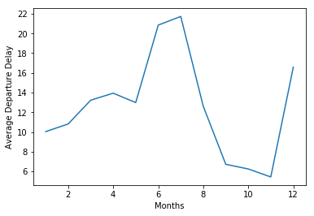

```python
#Analyzing the average departure delay of flights from New York throughout the year.
import matplotlib.pyplot as plt
%matplotlib inline
x=flights_df['month']
y=flights_df.groupby('month')['dep_delay'].mean()
plt.plot(y)
plt.xlabel('Months')
plt.ylabel('Average Departure Delay')
```

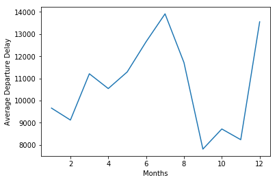

```python
#Analyzing the average number of delayed flights from New York throughout the year.

#Considering only the delayed flights to understand the seasonal pattern.
x=flights_df[flights_df['dep_delay'] >0]

#Grouping the data by months to get the counts.
y=x.groupby('month')['dep_delay'].count()
plt.plot(y)
plt.xlabel('Months')
plt.ylabel('Average Departure Delay')
```

Answer 2(c): There are seasonal patterns seen in the average departure delay as well as the number of delayed flights, which is represented by the spikes in the plot. We can see that the both these values are very high during the months of June, July and December which is the holiday season. We can expect that people would be travelling more during the holiday season which could lead to the increased departure delay and also more number of flights getting delayed.

(d) On average, how do departure delays vary over the course of a day?

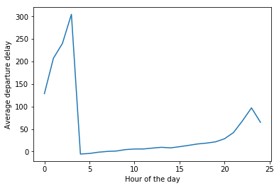

```python
#Analyzing the departure delay over the course of a day. During which hour of the day was the delay maximum.
y=flights_df.groupby('hour')['dep_delay'].mean()
plt.plot(y)
plt.xlabel('Hour of the day')
plt.ylabel('Average departure delay')
```

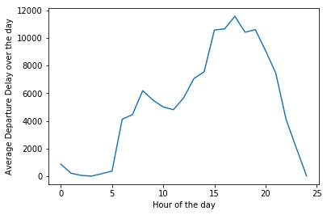

```python
#Number of flights that got delayed in a day. During which hour of the day were maximum flights delayed.
x=flights_df[flights_df['dep_delay'] >0]
y=x.groupby('hour')['dep_delay'].count()
plt.plot(y)
plt.xlabel("Hour of the day")
plt.ylabel("Average Departure Delay over the day")
```

## Question 3

```
Which flight departing NYC in 2013 flew the fastest?
```

```python
#Considering speed to be the factor corresponding to fastness
flights_df['speed']=flights_df['distance']/flights_df['air_time']
flights_df.sort_values('speed', ascending=False).head(1)
```

|  | Unnamed: 0 | year | month | day | dep_time | dep_delay | arr_time | arr_delay | carrier | tailnum | flight | origin | dest | air_time | distance | hour | minute | Date | speed |
| --- | --- | --- | --- | --- | --- | --- | --- | --- | --- | --- | --- | --- | --- | --- | --- | --- | --- | --- | --- |
| 216447 | 216448 | 2013 | 5 | 25 | 1709.0 | 9.0 | 1923.0 | -14.0 | DL | N666DN | 1499 | LGA | ATL | 65.0 | 762 | 17.0 | 9.0 | 5/25/2013 | 11.723077 |

Answer 3: The speed of the flight is calculated using the air time and distance of the travel. The fastest flight will have the highest speed. Thus flight DL 1499 with tail number N666DN flying from LGA to ATL is the fastest with a speed of 11.72 miles per minute.

## Question 4

Which flights (i.e. carrier + flight + dest) happen every day? Where do they fly to?

```python
# Obtaining the counts of the days by grouping into carrier, flight and destination. This gives a count of 365 for flights+carrier+dest combination to happen everyday.
carr_flight_dest=flights_df.groupby(['carrier','flight','dest']).count()
carr_flight_dest[carr_flight_dest['year']==365]
```

| carrier | flight | dest | Unnamed: 0 | year | month | day | dep_time | dep_delay | arr_time | arr_delay | tailnum | origin | air_time | distance | hour | minute | Date | speed |
| --- | --- | --- | --- | --- | --- | --- | --- | --- | --- | --- | --- | --- | --- | --- | --- | --- | --- | --- |
| AA | 59 | SFO | 365 | 365 | 365 | 365 | 359 | 359 | 359 | 359 | 363 | 365 | 359 | 365 | 359 | 359 | 365 | 359 |
|  | 119 | LAX | 365 | 365 | 365 | 365 | 361 | 361 | 361 | 359 | 364 | 365 | 359 | 365 | 361 | 361 | 365 | 359 |
|  | 181 | LAX | 365 | 365 | 365 | 365 | 363 | 363 | 363 | 362 | 365 | 365 | 362 | 365 | 363 | 363 | 365 | 362 |
|  | 1357 | SJU | 365 | 365 | 365 | 365 | 364 | 364 | 364 | 363 | 364 | 365 | 363 | 365 | 364 | 364 | 365 | 363 |
|  | 1611 | MIA | 365 | 365 | 365 | 365 | 360 | 360 | 360 | 360 | 364 | 365 | 360 | 365 | 360 | 360 | 365 | 360 |
| B6 | 219 | CLT | 365 | 365 | 365 | 365 | 363 | 363 | 363 | 363 | 365 | 365 | 363 | 365 | 363 | 363 | 365 | 363 |
|  | 359 | BUR | 365 | 365 | 365 | 365 | 364 | 364 | 364 | 364 | 365 | 365 | 364 | 365 | 364 | 364 | 365 | 364 |
|  | 371 | FLL | 365 | 365 | 365 | 365 | 359 | 359 | 359 | 359 | 365 | 365 | 359 | 365 | 359 | 359 | 365 | 359 |
|  | 431 | SRQ | 365 | 365 | 365 | 365 | 362 | 362 | 362 | 361 | 365 | 365 | 361 | 365 | 362 | 362 | 365 | 361 |
|  | 703 | SJU | 365 | 365 | 365 | 365 | 364 | 364 | 364 | 364 | 365 | 365 | 364 | 365 | 364 | 364 | 365 | 364 |
|  | 1783 | MCO | 365 | 365 | 365 | 365 | 365 | 365 | 365 | 365 | 365 | 365 | 365 | 365 | 365 | 365 | 365 | 365 |
| DL | 2159 | MCO | 365 | 365 | 365 | 365 | 364 | 364 | 364 | 364 | 365 | 365 | 364 | 365 | 364 | 364 | 365 | 364 |
|  | 2391 | TPA | 365 | 365 | 365 | 365 | 360 | 360 | 360 | 359 | 365 | 365 | 359 | 365 | 360 | 360 | 365 | 359 |
| EV | 5712 | IAD | 365 | 365 | 365 | 365 | 351 | 351 | 351 | 351 | 365 | 365 | 351 | 365 | 351 | 351 | 365 | 351 |
| UA | 15 | HNL | 365 | 365 | 365 | 365 | 363 | 363 | 363 | 359 | 363 | 365 | 359 | 365 | 363 | 363 | 365 | 359 |
| VX | 251 | LAS | 365 | 365 | 365 | 365 | 364 | 364 | 364 | 364 | 365 | 365 | 364 | 365 | 364 | 364 | 365 | 364 |
|  | 407 | LAX | 365 | 365 | 365 | 365 | 364 | 364 | 363 | 363 | 365 | 365 | 363 | 365 | 364 | 364 | 365 | 363 |
|  | 413 | LAX | 365 | 365 | 365 | 365 | 362 | 362 | 362 | 360 | 365 | 365 | 360 | 365 | 362 | 362 | 365 | 360 |

Answer 4: Carrier AA 59, AA 119, AA 181, AA 1357, AA 1611 B6 219, B6 359, B6 371, B6 431, B6 703, B6 1783, DL 2159, DL 2391, EV 5712, UA 15, VX 251, VX 407, VX 413 These are the flights that which fly everyday.

## Question 5

Develop one research question you can address using the nycflights2013 dataset. Provide two visualizations to support your exploration of this question. Discuss what you find.

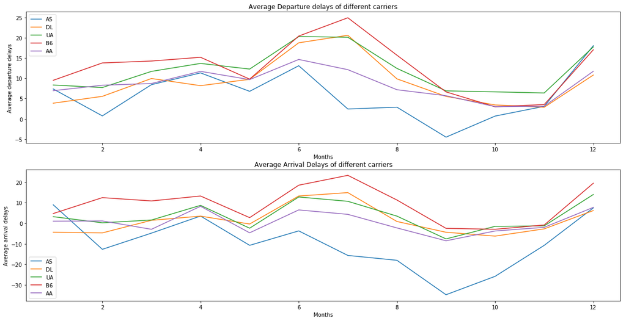

```python
#Research Question:
#Which carrier was the most efficient overall.

#Analyzing the average departure delay of different carriers throughtout the year
flights_df['carrier'].unique()
carrier_AS= flights_df[flights_df['carrier']=='AS']
carrier_AS
carrier_DL= flights_df[flights_df['carrier']=='DL']
carrier_DL
carrier_UA= flights_df[flights_df['carrier']=='UA']
carrier_UA
carrier_B6= flights_df[flights_df['carrier']=='B6']
carrier_B6
carrier_AA= flights_df[flights_df['carrier']=='AA']
carrier_AA

plt.figure(figsize=(20,10))
plt.subplot(2,1,1)
plt.plot(carrier_AS.groupby('month')['dep_delay'].mean(), label='AS')
plt.plot(carrier_DL.groupby('month')['dep_delay'].mean(), label='DL')
plt.plot(carrier_UA.groupby('month')['dep_delay'].mean(), label='UA')
plt.plot(carrier_B6.groupby('month')['dep_delay'].mean(), label='B6')
plt.plot(carrier_AA.groupby('month')['dep_delay'].mean(), label='AA')
plt.legend(loc='Upper right')
plt.title("Average Departure delays of different carriers")
plt.xlabel('Months')
plt.ylabel('Average departure delays')

#Analyzing the average Arrival delay of different carriers throughtout the year
flights_df['carrier'].unique()
carrier_AS= flights_df[flights_df['carrier']=='AS']
carrier_AS
carrier_DL= flights_df[flights_df['carrier']=='DL']
carrier_DL
carrier_UA= flights_df[flights_df['carrier']=='UA']
carrier_UA
carrier_B6= flights_df[flights_df['carrier']=='B6']
carrier_B6
carrier_AA= flights_df[flights_df['carrier']=='AA']
carrier_AA


plt.subplot(2,1,2)
plt.plot(carrier_AS.groupby('month')['arr_delay'].mean(), label='AS')
plt.plot(carrier_DL.groupby('month')['arr_delay'].mean(), label='DL')
plt.plot(carrier_UA.groupby('month')['arr_delay'].mean(), label='UA')
plt.plot(carrier_B6.groupby('month')['arr_delay'].mean(), label='B6')
plt.plot(carrier_AA.groupby('month')['arr_delay'].mean(), label='AA')
plt.legend(loc='Upper right')
plt.title("Average Arrival Delays of different carriers")
plt.xlabel('Months')
plt.ylabel('Average arrival delays')
```

Answer 5: The above two plots describe the average departure delays and average arrival delays for the different carriers during the course of the entire year. Analyzing this data would give interesting insights into the working of different carriers, especially from a seasonal context.

The AS carrier has the lowest departure and arrival delays for most parts, with only a significant increase seen during the month of december. Thus the AS carrier seems to be the most efficient in lowering the delays and providing better services to its customer.

Note: In the anlysis for this question, the number of flights flown by the carrier is not considered, but the consideration is only based on the delays a carrier has irrespective of the number of flights.

## Question 6

What weather conditions are associated with flight delays leaving NYC? Use graphics to explore.

```python
weather_df= pd.read_csv('weather.csv')
weather_df
```

|  | Unnamed: 0 | origin | year | month | day | hour | temp | dewp | humid | wind_dir | wind_speed | wind_gust | precip | pressure | visib |
| --- | --- | --- | --- | --- | --- | --- | --- | --- | --- | --- | --- | --- | --- | --- | --- |
| 0 | 1 | EWR | 2013 | 1.0 | 1.0 | 0.0 | 37.04 | 21.92 | 53.97 | 230.0 | 10.35702 | 11.918651 | 0.0 | 1013.9 | 10.0 |
| 1 | 2 | EWR | 2013 | 1.0 | 1.0 | 1.0 | 37.04 | 21.92 | 53.97 | 230.0 | 13.80936 | 15.891535 | 0.0 | 1013.0 | 10.0 |
| 2 | 3 | EWR | 2013 | 1.0 | 1.0 | 2.0 | 37.94 | 21.92 | 52.09 | 230.0 | 12.65858 | 14.567241 | 0.0 | 1012.6 | 10.0 |
| 3 | 4 | EWR | 2013 | 1.0 | 1.0 | 3.0 | 37.94 | 23.00 | 54.51 | 230.0 | 13.80936 | 15.891535 | 0.0 | 1012.7 | 10.0 |
| 4 | 5 | EWR | 2013 | 1.0 | 1.0 | 4.0 | 37.94 | 24.08 | 57.04 | 240.0 | 14.96014 | 17.215830 | 0.0 | 1012.8 | 10.0 |
| 5 | 6 | EWR | 2013 | 1.0 | 1.0 | 6.0 | 39.02 | 26.06 | 59.37 | 270.0 | 10.35702 | 11.918651 | 0.0 | 1012.0 | 10.0 |
| 6 | 7 | EWR | 2013 | 1.0 | 1.0 | 7.0 | 39.02 | 26.96 | 61.63 | 250.0 | 8.05546 | 9.270062 | 0.0 | 1012.3 | 10.0 |
| 7 | 8 | EWR | 2013 | 1.0 | 1.0 | 8.0 | 39.02 | 28.04 | 64.43 | 240.0 | 11.50780 | 13.242946 | 0.0 | 1012.5 | 10.0 |
| 8 | 9 | EWR | 2013 | 1.0 | 1.0 | 9.0 | 39.92 | 28.04 | 62.21 | 250.0 | 12.65858 | 14.567241 | 0.0 | 1012.2 | 10.0 |
| 9 | 10 | EWR | 2013 | 1.0 | 1.0 | 10.0 | 39.02 | 28.04 | 64.43 | 260.0 | 12.65858 | 14.567241 | 0.0 | 1011.9 | 10.0 |
| 10 | 11 | EWR | 2013 | 1.0 | 1.0 | 11.0 | 37.94 | 28.04 | 67.21 | 240.0 | 11.50780 | 13.242946 | 0.0 | 1012.4 | 10.0 |
| 11 | 12 | EWR | 2013 | 1.0 | 1.0 | 12.0 | 39.02 | 28.04 | 64.43 | 240.0 | 14.96014 | 17.215830 | 0.0 | 1012.2 | 10.0 |
| 12 | 13 | EWR | 2013 | 1.0 | 1.0 | 13.0 | 39.92 | 28.04 | 62.21 | 250.0 | 10.35702 | 11.918651 | 0.0 | 1012.2 | 10.0 |
| 13 | 14 | EWR | 2013 | 1.0 | 1.0 | 14.0 | 39.92 | 28.04 | 62.21 | 260.0 | 14.96014 | 17.215830 | 0.0 | 1012.7 | 10.0 |
| 14 | 15 | EWR | 2013 | 1.0 | 1.0 | 15.0 | 41.00 | 28.04 | 59.65 | 260.0 | 13.80936 | 15.891535 | 0.0 | 1012.4 | 10.0 |
| 15 | 16 | EWR | 2013 | 1.0 | 1.0 | 16.0 | 41.00 | 26.96 | 57.06 | 260.0 | 14.96014 | 17.215830 | 0.0 | 1011.4 | 10.0 |
| 16 | 17 | EWR | 2013 | 1.0 | 1.0 | 17.0 | 39.20 | 28.40 | 64.93 | 270.0 | 16.11092 | 18.540125 | 0.0 | NaN | 10.0 |
| 17 | 18 | EWR | 2013 | 1.0 | 1.0 | 18.0 | 39.20 | 28.40 | 64.93 | 330.0 | 14.96014 | 17.215830 | 0.0 | NaN | 10.0 |
| 18 | 19 | EWR | 2013 | 1.0 | 1.0 | 19.0 | 39.02 | 24.08 | 54.68 | 280.0 | 13.80936 | 15.891535 | 0.0 | 1010.8 | 10.0 |
| 19 | 20 | EWR | 2013 | 1.0 | 1.0 | 20.0 | 37.94 | 24.08 | 57.04 | 290.0 | 9.20624 | 10.594357 | 0.0 | 1011.9 | 10.0 |
| 20 | 21 | EWR | 2013 | 1.0 | 1.0 | 21.0 | 37.04 | 19.94 | 49.62 | 300.0 | 13.80936 | 15.891535 | 0.0 | 1012.1 | 10.0 |
| 21 | 22 | EWR | 2013 | 1.0 | 1.0 | 22.0 | 35.96 | 19.04 | 49.83 | 330.0 | 11.50780 | 13.242946 | 0.0 | 1013.2 | 10.0 |
| 22 | 23 | EWR | 2013 | 1.0 | 1.0 | 23.0 | 33.98 | 15.08 | 45.43 | 310.0 | 12.65858 | 14.567241 | 0.0 | 1014.1 | 10.0 |
| 23 | 24 | EWR | 2013 | 1.0 | 2.0 | 0.0 | 33.08 | 12.92 | 42.84 | 320.0 | 10.35702 | 11.918651 | 0.0 | 1014.4 | 10.0 |
| 24 | 25 | EWR | 2013 | 1.0 | 2.0 | 1.0 | 32.00 | 15.08 | 49.19 | 310.0 | 14.96014 | 17.215830 | 0.0 | 1015.2 | 10.0 |
| 25 | 26 | EWR | 2013 | 1.0 | 2.0 | 2.0 | 30.02 | 12.92 | 48.48 | 320.0 | 18.41248 | 21.188714 | 0.0 | 1016.0 | 10.0 |
| 26 | 27 | EWR | 2013 | 1.0 | 2.0 | 3.0 | 28.94 | 12.02 | 48.69 | 320.0 | 18.41248 | 21.188714 | 0.0 | 1016.5 | 10.0 |
| 27 | 28 | EWR | 2013 | 1.0 | 2.0 | 4.0 | 28.04 | 10.94 | 48.15 | 310.0 | 16.11092 | 18.540125 | 0.0 | 1016.4 | 10.0 |
| 28 | 29 | EWR | 2013 | 1.0 | 2.0 | 5.0 | 26.96 | 10.94 | 50.34 | 310.0 | 14.96014 | 17.215830 | 0.0 | 1016.3 | 10.0 |
| 29 | 30 | EWR | 2013 | 1.0 | 2.0 | 6.0 | 26.06 | 10.94 | 52.25 | 330.0 | 12.65858 | 14.567241 | 0.0 | 1016.3 | 10.0 |
| ... | ... | ... | ... | ... | ... | ... | ... | ... | ... | ... | ... | ... | ... | ... | ... |
| 8689 | 8690 | EWR | 2013 | 12.0 | 30.0 | 4.0 | 42.08 | 35.96 | 78.74 | 280.0 | 13.80936 | 15.891535 | 0.0 | 1005.6 | 10.0 |
| 8690 | 8691 | EWR | 2013 | 12.0 | 30.0 | 5.0 | 41.00 | 35.96 | 82.09 | 260.0 | 5.75390 | 6.621473 | 0.0 | 1006.5 | 10.0 |
| 8691 | 8692 | EWR | 2013 | 12.0 | 30.0 | 6.0 | 37.94 | 33.98 | 85.49 | 220.0 | 6.90468 | 7.945768 | 0.0 | 1008.1 | 10.0 |
| 8692 | 8693 | EWR | 2013 | 12.0 | 30.0 | 7.0 | 37.04 | 33.98 | 88.57 | 220.0 | 8.05546 | 9.270062 | 0.0 | 1008.6 | 10.0 |
| 8693 | 8694 | EWR | 2013 | 12.0 | 30.0 | 8.0 | 37.04 | 35.96 | 95.82 | 230.0 | 4.60312 | 5.297178 | 0.0 | 1008.5 | 10.0 |
| 8694 | 8695 | EWR | 2013 | 12.0 | 30.0 | 9.0 | 37.94 | 35.96 | 92.49 | 230.0 | 8.05546 | 9.270062 | 0.0 | 1009.5 | 10.0 |
| 8695 | 8696 | EWR | 2013 | 12.0 | 30.0 | 10.0 | 37.04 | 35.06 | 92.46 | 220.0 | 8.05546 | 9.270062 | 0.0 | 1010.1 | 10.0 |
| 8696 | 8697 | EWR | 2013 | 12.0 | 30.0 | 11.0 | 39.02 | 35.96 | 88.66 | 230.0 | 8.05546 | 9.270062 | 0.0 | 1011.3 | 10.0 |
| 8697 | 8698 | EWR | 2013 | 12.0 | 30.0 | 12.0 | 39.92 | 37.04 | 89.34 | 240.0 | 8.05546 | 9.270062 | 0.0 | 1012.3 | 10.0 |
| 8698 | 8699 | EWR | 2013 | 12.0 | 30.0 | 13.0 | 42.08 | 37.04 | 82.17 | 240.0 | 10.35702 | 11.918651 | 0.0 | 1013.2 | 10.0 |
| 8699 | 8700 | EWR | 2013 | 12.0 | 30.0 | 14.0 | 44.96 | 37.04 | 73.59 | 260.0 | 10.35702 | 11.918651 | 0.0 | 1014.0 | 10.0 |
| 8700 | 8701 | EWR | 2013 | 12.0 | 30.0 | 15.0 | 42.98 | 32.00 | 64.93 | 320.0 | 13.80936 | 15.891535 | 0.0 | 1015.0 | 10.0 |
| 8701 | 8702 | EWR | 2013 | 12.0 | 30.0 | 16.0 | 41.00 | 28.94 | 61.89 | 330.0 | 14.96014 | 17.215830 | 0.0 | 1015.1 | 10.0 |
| 8702 | 8703 | EWR | 2013 | 12.0 | 30.0 | 17.0 | 39.92 | 26.06 | 57.33 | 320.0 | 13.80936 | 15.891535 | 0.0 | 1015.9 | 10.0 |
| 8703 | 8704 | EWR | 2013 | 12.0 | 30.0 | 18.0 | 37.94 | 23.00 | 54.51 | 330.0 | 19.56326 | 22.513008 | 0.0 | 1016.7 | 10.0 |
| 8704 | 8705 | EWR | 2013 | 12.0 | 30.0 | 19.0 | 37.04 | 21.02 | 51.95 | 320.0 | 17.26170 | 19.864419 | 0.0 | 1017.6 | 10.0 |
| 8705 | 8706 | EWR | 2013 | 12.0 | 30.0 | 20.0 | 35.06 | 17.96 | 49.30 | 340.0 | 17.26170 | 19.864419 | 0.0 | 1019.1 | 10.0 |
| 8706 | 8707 | EWR | 2013 | 12.0 | 30.0 | 21.0 | 33.08 | 15.98 | 48.98 | 320.0 | 14.96014 | 17.215830 | 0.0 | 1019.8 | 10.0 |
| 8707 | 8708 | EWR | 2013 | 12.0 | 30.0 | 22.0 | 30.92 | 12.92 | 46.74 | 340.0 | 16.11092 | 18.540125 | 0.0 | 1020.5 | 10.0 |
| 8708 | 8709 | EWR | 2013 | 12.0 | 30.0 | 23.0 | 28.94 | 12.02 | 48.69 | 330.0 | 14.96014 | 17.215830 | 0.0 | 1021.1 | 10.0 |
| 8709 | 8710 | JFK | 2013 | 2.0 | 18.0 | 4.0 | 17.96 | -0.94 | 42.69 | 290.0 | 29.92028 | 34.431660 | 0.0 | 1016.2 | 10.0 |
| 8710 | 8711 | JFK | 2013 | 2.0 | 20.0 | 19.0 | 32.00 | 8.06 | 36.03 | 280.0 | 26.46794 | 30.458776 | 0.0 | 1011.2 | 10.0 |
| 8711 | 8712 | JFK | 2013 | 7.0 | 2.0 | 11.0 | 71.60 | 69.80 | 94.06 | 180.0 | 11.50780 | 13.242946 | 0.0 | NaN | 0.5 |
| 8712 | 8713 | JFK | 2013 | 7.0 | 2.0 | 13.0 | 71.60 | 69.80 | 94.06 | 190.0 | 10.35702 | 11.918651 | 0.0 | NaN | 1.0 |
| 8713 | 8714 | JFK | 2013 | 7.0 | 31.0 | 6.0 | 71.06 | 55.04 | 56.93 | 320.0 | 8.05546 | 9.270062 | 0.0 | 1020.4 | 10.0 |
| 8714 | 8715 | JFK | 2013 | 9.0 | 2.0 | 20.0 | 75.20 | 73.40 | 94.14 | 200.0 | 4.60312 | 5.297178 | 0.0 | NaN | 4.0 |
| 8715 | 8716 | JFK | 2013 | 10.0 | 23.0 | 10.0 | 48.92 | 39.02 | 68.51 | 60.0 | 4.60312 | 5.297178 | 0.0 | 1008.1 | 10.0 |
| 8716 | 8717 | JFK | 2013 | 10.0 | 23.0 | 11.0 | 48.92 | 39.02 | 68.51 | 40.0 | 4.60312 | 5.297178 | 0.0 | 1008.5 | 10.0 |
| 8717 | 8718 | JFK | 2013 | 12.0 | 17.0 | 5.0 | 26.96 | 10.94 | 50.34 | 40.0 | 4.60312 | 5.297178 | 0.0 | 1023.9 | 10.0 |
| 8718 | 8719 | LGA | 2013 | 8.0 | 22.0 | 22.0 | 75.92 | 66.92 | 73.68 | 210.0 | 8.05546 | 9.270062 | 0.0 | 1011.9 | 10.0 |

8719 rows × 15 columns

```python
#Retaining only the required columns in the weather_df
weather_df= pd.DataFrame(weather_df[['origin','year','month','day','hour','temp','dewp','humid','wind_dir','wind_speed','wind_gust','precip','pressure','visib']])
weather_df
```

|  | origin | year | month | day | hour | temp | dewp | humid | wind_dir | wind_speed | wind_gust | precip | pressure | visib |
| --- | --- | --- | --- | --- | --- | --- | --- | --- | --- | --- | --- | --- | --- | --- |
| 0 | EWR | 2013 | 1.0 | 1.0 | 0.0 | 37.04 | 21.92 | 53.97 | 230.0 | 10.35702 | 11.918651 | 0.0 | 1013.9 | 10.0 |
| 1 | EWR | 2013 | 1.0 | 1.0 | 1.0 | 37.04 | 21.92 | 53.97 | 230.0 | 13.80936 | 15.891535 | 0.0 | 1013.0 | 10.0 |
| 2 | EWR | 2013 | 1.0 | 1.0 | 2.0 | 37.94 | 21.92 | 52.09 | 230.0 | 12.65858 | 14.567241 | 0.0 | 1012.6 | 10.0 |
| 3 | EWR | 2013 | 1.0 | 1.0 | 3.0 | 37.94 | 23.00 | 54.51 | 230.0 | 13.80936 | 15.891535 | 0.0 | 1012.7 | 10.0 |
| 4 | EWR | 2013 | 1.0 | 1.0 | 4.0 | 37.94 | 24.08 | 57.04 | 240.0 | 14.96014 | 17.215830 | 0.0 | 1012.8 | 10.0 |
| 5 | EWR | 2013 | 1.0 | 1.0 | 6.0 | 39.02 | 26.06 | 59.37 | 270.0 | 10.35702 | 11.918651 | 0.0 | 1012.0 | 10.0 |
| 6 | EWR | 2013 | 1.0 | 1.0 | 7.0 | 39.02 | 26.96 | 61.63 | 250.0 | 8.05546 | 9.270062 | 0.0 | 1012.3 | 10.0 |
| 7 | EWR | 2013 | 1.0 | 1.0 | 8.0 | 39.02 | 28.04 | 64.43 | 240.0 | 11.50780 | 13.242946 | 0.0 | 1012.5 | 10.0 |
| 8 | EWR | 2013 | 1.0 | 1.0 | 9.0 | 39.92 | 28.04 | 62.21 | 250.0 | 12.65858 | 14.567241 | 0.0 | 1012.2 | 10.0 |
| 9 | EWR | 2013 | 1.0 | 1.0 | 10.0 | 39.02 | 28.04 | 64.43 | 260.0 | 12.65858 | 14.567241 | 0.0 | 1011.9 | 10.0 |
| 10 | EWR | 2013 | 1.0 | 1.0 | 11.0 | 37.94 | 28.04 | 67.21 | 240.0 | 11.50780 | 13.242946 | 0.0 | 1012.4 | 10.0 |
| 11 | EWR | 2013 | 1.0 | 1.0 | 12.0 | 39.02 | 28.04 | 64.43 | 240.0 | 14.96014 | 17.215830 | 0.0 | 1012.2 | 10.0 |
| 12 | EWR | 2013 | 1.0 | 1.0 | 13.0 | 39.92 | 28.04 | 62.21 | 250.0 | 10.35702 | 11.918651 | 0.0 | 1012.2 | 10.0 |
| 13 | EWR | 2013 | 1.0 | 1.0 | 14.0 | 39.92 | 28.04 | 62.21 | 260.0 | 14.96014 | 17.215830 | 0.0 | 1012.7 | 10.0 |
| 14 | EWR | 2013 | 1.0 | 1.0 | 15.0 | 41.00 | 28.04 | 59.65 | 260.0 | 13.80936 | 15.891535 | 0.0 | 1012.4 | 10.0 |
| 15 | EWR | 2013 | 1.0 | 1.0 | 16.0 | 41.00 | 26.96 | 57.06 | 260.0 | 14.96014 | 17.215830 | 0.0 | 1011.4 | 10.0 |
| 16 | EWR | 2013 | 1.0 | 1.0 | 17.0 | 39.20 | 28.40 | 64.93 | 270.0 | 16.11092 | 18.540125 | 0.0 | NaN | 10.0 |
| 17 | EWR | 2013 | 1.0 | 1.0 | 18.0 | 39.20 | 28.40 | 64.93 | 330.0 | 14.96014 | 17.215830 | 0.0 | NaN | 10.0 |
| 18 | EWR | 2013 | 1.0 | 1.0 | 19.0 | 39.02 | 24.08 | 54.68 | 280.0 | 13.80936 | 15.891535 | 0.0 | 1010.8 | 10.0 |
| 19 | EWR | 2013 | 1.0 | 1.0 | 20.0 | 37.94 | 24.08 | 57.04 | 290.0 | 9.20624 | 10.594357 | 0.0 | 1011.9 | 10.0 |
| 20 | EWR | 2013 | 1.0 | 1.0 | 21.0 | 37.04 | 19.94 | 49.62 | 300.0 | 13.80936 | 15.891535 | 0.0 | 1012.1 | 10.0 |
| 21 | EWR | 2013 | 1.0 | 1.0 | 22.0 | 35.96 | 19.04 | 49.83 | 330.0 | 11.50780 | 13.242946 | 0.0 | 1013.2 | 10.0 |
| 22 | EWR | 2013 | 1.0 | 1.0 | 23.0 | 33.98 | 15.08 | 45.43 | 310.0 | 12.65858 | 14.567241 | 0.0 | 1014.1 | 10.0 |
| 23 | EWR | 2013 | 1.0 | 2.0 | 0.0 | 33.08 | 12.92 | 42.84 | 320.0 | 10.35702 | 11.918651 | 0.0 | 1014.4 | 10.0 |
| 24 | EWR | 2013 | 1.0 | 2.0 | 1.0 | 32.00 | 15.08 | 49.19 | 310.0 | 14.96014 | 17.215830 | 0.0 | 1015.2 | 10.0 |
| 25 | EWR | 2013 | 1.0 | 2.0 | 2.0 | 30.02 | 12.92 | 48.48 | 320.0 | 18.41248 | 21.188714 | 0.0 | 1016.0 | 10.0 |
| 26 | EWR | 2013 | 1.0 | 2.0 | 3.0 | 28.94 | 12.02 | 48.69 | 320.0 | 18.41248 | 21.188714 | 0.0 | 1016.5 | 10.0 |
| 27 | EWR | 2013 | 1.0 | 2.0 | 4.0 | 28.04 | 10.94 | 48.15 | 310.0 | 16.11092 | 18.540125 | 0.0 | 1016.4 | 10.0 |
| 28 | EWR | 2013 | 1.0 | 2.0 | 5.0 | 26.96 | 10.94 | 50.34 | 310.0 | 14.96014 | 17.215830 | 0.0 | 1016.3 | 10.0 |
| 29 | EWR | 2013 | 1.0 | 2.0 | 6.0 | 26.06 | 10.94 | 52.25 | 330.0 | 12.65858 | 14.567241 | 0.0 | 1016.3 | 10.0 |
| ... | ... | ... | ... | ... | ... | ... | ... | ... | ... | ... | ... | ... | ... | ... |
| 8689 | EWR | 2013 | 12.0 | 30.0 | 4.0 | 42.08 | 35.96 | 78.74 | 280.0 | 13.80936 | 15.891535 | 0.0 | 1005.6 | 10.0 |
| 8690 | EWR | 2013 | 12.0 | 30.0 | 5.0 | 41.00 | 35.96 | 82.09 | 260.0 | 5.75390 | 6.621473 | 0.0 | 1006.5 | 10.0 |
| 8691 | EWR | 2013 | 12.0 | 30.0 | 6.0 | 37.94 | 33.98 | 85.49 | 220.0 | 6.90468 | 7.945768 | 0.0 | 1008.1 | 10.0 |
| 8692 | EWR | 2013 | 12.0 | 30.0 | 7.0 | 37.04 | 33.98 | 88.57 | 220.0 | 8.05546 | 9.270062 | 0.0 | 1008.6 | 10.0 |
| 8693 | EWR | 2013 | 12.0 | 30.0 | 8.0 | 37.04 | 35.96 | 95.82 | 230.0 | 4.60312 | 5.297178 | 0.0 | 1008.5 | 10.0 |
| 8694 | EWR | 2013 | 12.0 | 30.0 | 9.0 | 37.94 | 35.96 | 92.49 | 230.0 | 8.05546 | 9.270062 | 0.0 | 1009.5 | 10.0 |
| 8695 | EWR | 2013 | 12.0 | 30.0 | 10.0 | 37.04 | 35.06 | 92.46 | 220.0 | 8.05546 | 9.270062 | 0.0 | 1010.1 | 10.0 |
| 8696 | EWR | 2013 | 12.0 | 30.0 | 11.0 | 39.02 | 35.96 | 88.66 | 230.0 | 8.05546 | 9.270062 | 0.0 | 1011.3 | 10.0 |
| 8697 | EWR | 2013 | 12.0 | 30.0 | 12.0 | 39.92 | 37.04 | 89.34 | 240.0 | 8.05546 | 9.270062 | 0.0 | 1012.3 | 10.0 |
| 8698 | EWR | 2013 | 12.0 | 30.0 | 13.0 | 42.08 | 37.04 | 82.17 | 240.0 | 10.35702 | 11.918651 | 0.0 | 1013.2 | 10.0 |
| 8699 | EWR | 2013 | 12.0 | 30.0 | 14.0 | 44.96 | 37.04 | 73.59 | 260.0 | 10.35702 | 11.918651 | 0.0 | 1014.0 | 10.0 |
| 8700 | EWR | 2013 | 12.0 | 30.0 | 15.0 | 42.98 | 32.00 | 64.93 | 320.0 | 13.80936 | 15.891535 | 0.0 | 1015.0 | 10.0 |
| 8701 | EWR | 2013 | 12.0 | 30.0 | 16.0 | 41.00 | 28.94 | 61.89 | 330.0 | 14.96014 | 17.215830 | 0.0 | 1015.1 | 10.0 |
| 8702 | EWR | 2013 | 12.0 | 30.0 | 17.0 | 39.92 | 26.06 | 57.33 | 320.0 | 13.80936 | 15.891535 | 0.0 | 1015.9 | 10.0 |
| 8703 | EWR | 2013 | 12.0 | 30.0 | 18.0 | 37.94 | 23.00 | 54.51 | 330.0 | 19.56326 | 22.513008 | 0.0 | 1016.7 | 10.0 |
| 8704 | EWR | 2013 | 12.0 | 30.0 | 19.0 | 37.04 | 21.02 | 51.95 | 320.0 | 17.26170 | 19.864419 | 0.0 | 1017.6 | 10.0 |
| 8705 | EWR | 2013 | 12.0 | 30.0 | 20.0 | 35.06 | 17.96 | 49.30 | 340.0 | 17.26170 | 19.864419 | 0.0 | 1019.1 | 10.0 |
| 8706 | EWR | 2013 | 12.0 | 30.0 | 21.0 | 33.08 | 15.98 | 48.98 | 320.0 | 14.96014 | 17.215830 | 0.0 | 1019.8 | 10.0 |
| 8707 | EWR | 2013 | 12.0 | 30.0 | 22.0 | 30.92 | 12.92 | 46.74 | 340.0 | 16.11092 | 18.540125 | 0.0 | 1020.5 | 10.0 |
| 8708 | EWR | 2013 | 12.0 | 30.0 | 23.0 | 28.94 | 12.02 | 48.69 | 330.0 | 14.96014 | 17.215830 | 0.0 | 1021.1 | 10.0 |
| 8709 | JFK | 2013 | 2.0 | 18.0 | 4.0 | 17.96 | -0.94 | 42.69 | 290.0 | 29.92028 | 34.431660 | 0.0 | 1016.2 | 10.0 |
| 8710 | JFK | 2013 | 2.0 | 20.0 | 19.0 | 32.00 | 8.06 | 36.03 | 280.0 | 26.46794 | 30.458776 | 0.0 | 1011.2 | 10.0 |
| 8711 | JFK | 2013 | 7.0 | 2.0 | 11.0 | 71.60 | 69.80 | 94.06 | 180.0 | 11.50780 | 13.242946 | 0.0 | NaN | 0.5 |
| 8712 | JFK | 2013 | 7.0 | 2.0 | 13.0 | 71.60 | 69.80 | 94.06 | 190.0 | 10.35702 | 11.918651 | 0.0 | NaN | 1.0 |
| 8713 | JFK | 2013 | 7.0 | 31.0 | 6.0 | 71.06 | 55.04 | 56.93 | 320.0 | 8.05546 | 9.270062 | 0.0 | 1020.4 | 10.0 |
| 8714 | JFK | 2013 | 9.0 | 2.0 | 20.0 | 75.20 | 73.40 | 94.14 | 200.0 | 4.60312 | 5.297178 | 0.0 | NaN | 4.0 |
| 8715 | JFK | 2013 | 10.0 | 23.0 | 10.0 | 48.92 | 39.02 | 68.51 | 60.0 | 4.60312 | 5.297178 | 0.0 | 1008.1 | 10.0 |
| 8716 | JFK | 2013 | 10.0 | 23.0 | 11.0 | 48.92 | 39.02 | 68.51 | 40.0 | 4.60312 | 5.297178 | 0.0 | 1008.5 | 10.0 |
| 8717 | JFK | 2013 | 12.0 | 17.0 | 5.0 | 26.96 | 10.94 | 50.34 | 40.0 | 4.60312 | 5.297178 | 0.0 | 1023.9 | 10.0 |
| 8718 | LGA | 2013 | 8.0 | 22.0 | 22.0 | 75.92 | 66.92 | 73.68 | 210.0 | 8.05546 | 9.270062 | 0.0 | 1011.9 | 10.0 |

8719 rows × 14 columns

```python
#Considering only the flights leaving New York, ie.JFK, EWR and LGA airports
nyc_flights= flights_df[((flights_df['origin']=='JFK') | (flights_df['origin']=='EWR') | (flights_df['origin']=='LGA'))]
nyc_flights
```

|  | Unnamed: 0 | year | month | day | dep_time | dep_delay | arr_time | arr_delay | carrier | tailnum | flight | origin | dest | air_time | distance | hour | minute | Date | speed |
| --- | --- | --- | --- | --- | --- | --- | --- | --- | --- | --- | --- | --- | --- | --- | --- | --- | --- | --- | --- |
| 0 | 1 | 2013 | 1 | 1 | 517.0 | 2.0 | 830.0 | 11.0 | UA | N14228 | 1545 | EWR | IAH | 227.0 | 1400 | 5.0 | 17.0 | 1/1/2013 | 6.167401 |
| 1 | 2 | 2013 | 1 | 1 | 533.0 | 4.0 | 850.0 | 20.0 | UA | N24211 | 1714 | LGA | IAH | 227.0 | 1416 | 5.0 | 33.0 | 1/1/2013 | 6.237885 |
| 2 | 3 | 2013 | 1 | 1 | 542.0 | 2.0 | 923.0 | 33.0 | AA | N619AA | 1141 | JFK | MIA | 160.0 | 1089 | 5.0 | 42.0 | 1/1/2013 | 6.806250 |
| 3 | 4 | 2013 | 1 | 1 | 544.0 | -1.0 | 1004.0 | -18.0 | B6 | N804JB | 725 | JFK | BQN | 183.0 | 1576 | 5.0 | 44.0 | 1/1/2013 | 8.612022 |
| 4 | 5 | 2013 | 1 | 1 | 554.0 | -6.0 | 812.0 | -25.0 | DL | N668DN | 461 | LGA | ATL | 116.0 | 762 | 5.0 | 54.0 | 1/1/2013 | 6.568966 |
| 5 | 6 | 2013 | 1 | 1 | 554.0 | -4.0 | 740.0 | 12.0 | UA | N39463 | 1696 | EWR | ORD | 150.0 | 719 | 5.0 | 54.0 | 1/1/2013 | 4.793333 |
| 6 | 7 | 2013 | 1 | 1 | 555.0 | -5.0 | 913.0 | 19.0 | B6 | N516JB | 507 | EWR | FLL | 158.0 | 1065 | 5.0 | 55.0 | 1/1/2013 | 6.740506 |
| 7 | 8 | 2013 | 1 | 1 | 557.0 | -3.0 | 709.0 | -14.0 | EV | N829AS | 5708 | LGA | IAD | 53.0 | 229 | 5.0 | 57.0 | 1/1/2013 | 4.320755 |
| 8 | 9 | 2013 | 1 | 1 | 557.0 | -3.0 | 838.0 | -8.0 | B6 | N593JB | 79 | JFK | MCO | 140.0 | 944 | 5.0 | 57.0 | 1/1/2013 | 6.742857 |
| 9 | 10 | 2013 | 1 | 1 | 558.0 | -2.0 | 753.0 | 8.0 | AA | N3ALAA | 301 | LGA | ORD | 138.0 | 733 | 5.0 | 58.0 | 1/1/2013 | 5.311594 |
| 10 | 11 | 2013 | 1 | 1 | 558.0 | -2.0 | 849.0 | -2.0 | B6 | N793JB | 49 | JFK | PBI | 149.0 | 1028 | 5.0 | 58.0 | 1/1/2013 | 6.899329 |
| 11 | 12 | 2013 | 1 | 1 | 558.0 | -2.0 | 853.0 | -3.0 | B6 | N657JB | 71 | JFK | TPA | 158.0 | 1005 | 5.0 | 58.0 | 1/1/2013 | 6.360759 |
| 12 | 13 | 2013 | 1 | 1 | 558.0 | -2.0 | 924.0 | 7.0 | UA | N29129 | 194 | JFK | LAX | 345.0 | 2475 | 5.0 | 58.0 | 1/1/2013 | 7.173913 |
| 13 | 14 | 2013 | 1 | 1 | 558.0 | -2.0 | 923.0 | -14.0 | UA | N53441 | 1124 | EWR | SFO | 361.0 | 2565 | 5.0 | 58.0 | 1/1/2013 | 7.105263 |
| 14 | 15 | 2013 | 1 | 1 | 559.0 | -1.0 | 941.0 | 31.0 | AA | N3DUAA | 707 | LGA | DFW | 257.0 | 1389 | 5.0 | 59.0 | 1/1/2013 | 5.404669 |
| 15 | 16 | 2013 | 1 | 1 | 559.0 | 0.0 | 702.0 | -4.0 | B6 | N708JB | 1806 | JFK | BOS | 44.0 | 187 | 5.0 | 59.0 | 1/1/2013 | 4.250000 |
| 16 | 17 | 2013 | 1 | 1 | 559.0 | -1.0 | 854.0 | -8.0 | UA | N76515 | 1187 | EWR | LAS | 337.0 | 2227 | 5.0 | 59.0 | 1/1/2013 | 6.608309 |
| 17 | 18 | 2013 | 1 | 1 | 600.0 | 0.0 | 851.0 | -7.0 | B6 | N595JB | 371 | LGA | FLL | 152.0 | 1076 | 6.0 | 0.0 | 1/1/2013 | 7.078947 |
| 18 | 19 | 2013 | 1 | 1 | 600.0 | 0.0 | 837.0 | 12.0 | MQ | N542MQ | 4650 | LGA | ATL | 134.0 | 762 | 6.0 | 0.0 | 1/1/2013 | 5.686567 |
| 19 | 20 | 2013 | 1 | 1 | 601.0 | 1.0 | 844.0 | -6.0 | B6 | N644JB | 343 | EWR | PBI | 147.0 | 1023 | 6.0 | 1.0 | 1/1/2013 | 6.959184 |
| 20 | 21 | 2013 | 1 | 1 | 602.0 | -8.0 | 812.0 | -8.0 | DL | N971DL | 1919 | LGA | MSP | 170.0 | 1020 | 6.0 | 2.0 | 1/1/2013 | 6.000000 |
| 21 | 22 | 2013 | 1 | 1 | 602.0 | -3.0 | 821.0 | 16.0 | MQ | N730MQ | 4401 | LGA | DTW | 105.0 | 502 | 6.0 | 2.0 | 1/1/2013 | 4.780952 |
| 22 | 23 | 2013 | 1 | 1 | 606.0 | -4.0 | 858.0 | -12.0 | AA | N633AA | 1895 | EWR | MIA | 152.0 | 1085 | 6.0 | 6.0 | 1/1/2013 | 7.138158 |
| 23 | 24 | 2013 | 1 | 1 | 606.0 | -4.0 | 837.0 | -8.0 | DL | N3739P | 1743 | JFK | ATL | 128.0 | 760 | 6.0 | 6.0 | 1/1/2013 | 5.937500 |
| 24 | 25 | 2013 | 1 | 1 | 607.0 | 0.0 | 858.0 | -17.0 | UA | N53442 | 1077 | EWR | MIA | 157.0 | 1085 | 6.0 | 7.0 | 1/1/2013 | 6.910828 |
| 25 | 26 | 2013 | 1 | 1 | 608.0 | 8.0 | 807.0 | 32.0 | MQ | N9EAMQ | 3768 | EWR | ORD | 139.0 | 719 | 6.0 | 8.0 | 1/1/2013 | 5.172662 |
| 26 | 27 | 2013 | 1 | 1 | 611.0 | 11.0 | 945.0 | 14.0 | UA | N532UA | 303 | JFK | SFO | 366.0 | 2586 | 6.0 | 11.0 | 1/1/2013 | 7.065574 |
| 27 | 28 | 2013 | 1 | 1 | 613.0 | 3.0 | 925.0 | 4.0 | B6 | N635JB | 135 | JFK | RSW | 175.0 | 1074 | 6.0 | 13.0 | 1/1/2013 | 6.137143 |
| 28 | 29 | 2013 | 1 | 1 | 615.0 | 0.0 | 1039.0 | -21.0 | B6 | N794JB | 709 | JFK | SJU | 182.0 | 1598 | 6.0 | 15.0 | 1/1/2013 | 8.780220 |
| 29 | 30 | 2013 | 1 | 1 | 615.0 | 0.0 | 833.0 | -9.0 | DL | N326NB | 575 | EWR | ATL | 120.0 | 746 | 6.0 | 15.0 | 1/1/2013 | 6.216667 |
| ... | ... | ... | ... | ... | ... | ... | ... | ... | ... | ... | ... | ... | ... | ... | ... | ... | ... | ... | ... |
| 336746 | 336747 | 2013 | 9 | 30 | 2123.0 | -2.0 | 2223.0 | -24.0 | EV | N712EV | 5489 | LGA | CHO | 45.0 | 305 | 21.0 | 23.0 | 9/30/2013 | 6.777778 |
| 336747 | 336748 | 2013 | 9 | 30 | 2127.0 | -2.0 | 2314.0 | -9.0 | EV | N16546 | 3833 | EWR | CLT | 72.0 | 529 | 21.0 | 27.0 | 9/30/2013 | 7.347222 |
| 336748 | 336749 | 2013 | 9 | 30 | 2128.0 | -2.0 | 2328.0 | -31.0 | B6 | N807JB | 97 | JFK | DEN | 213.0 | 1626 | 21.0 | 28.0 | 9/30/2013 | 7.633803 |
| 336749 | 336750 | 2013 | 9 | 30 | 2129.0 | 30.0 | 2230.0 | -2.0 | EV | N751EV | 5048 | LGA | RIC | 45.0 | 292 | 21.0 | 29.0 | 9/30/2013 | 6.488889 |
| 336750 | 336751 | 2013 | 9 | 30 | 2131.0 | -9.0 | 2225.0 | -30.0 | MQ | N807MQ | 3621 | JFK | DCA | 36.0 | 213 | 21.0 | 31.0 | 9/30/2013 | 5.916667 |
| 336751 | 336752 | 2013 | 9 | 30 | 2140.0 | 0.0 | 10.0 | -30.0 | AA | N335AA | 185 | JFK | LAX | 298.0 | 2475 | 21.0 | 40.0 | 9/30/2013 | 8.305369 |
| 336752 | 336753 | 2013 | 9 | 30 | 2142.0 | 13.0 | 2250.0 | 11.0 | EV | N12957 | 4509 | EWR | PWM | 47.0 | 284 | 21.0 | 42.0 | 9/30/2013 | 6.042553 |
| 336753 | 336754 | 2013 | 9 | 30 | 2145.0 | 0.0 | 115.0 | -25.0 | B6 | N633JB | 1103 | JFK | SJU | 192.0 | 1598 | 21.0 | 45.0 | 9/30/2013 | 8.322917 |
| 336754 | 336755 | 2013 | 9 | 30 | 2147.0 | 10.0 | 30.0 | 3.0 | B6 | N627JB | 1371 | LGA | FLL | 139.0 | 1076 | 21.0 | 47.0 | 9/30/2013 | 7.741007 |
| 336755 | 336756 | 2013 | 9 | 30 | 2149.0 | -7.0 | 2245.0 | -23.0 | UA | N813UA | 523 | EWR | BOS | 37.0 | 200 | 21.0 | 49.0 | 9/30/2013 | 5.405405 |
| 336756 | 336757 | 2013 | 9 | 30 | 2150.0 | -9.0 | 2250.0 | -16.0 | EV | N10575 | 3842 | EWR | MHT | 39.0 | 209 | 21.0 | 50.0 | 9/30/2013 | 5.358974 |
| 336757 | 336758 | 2013 | 9 | 30 | 2159.0 | 194.0 | 2344.0 | 194.0 | 9E | N906XJ | 3320 | JFK | BUF | 50.0 | 301 | 21.0 | 59.0 | 9/30/2013 | 6.020000 |
| 336758 | 336759 | 2013 | 9 | 30 | 2203.0 | -2.0 | 2339.0 | 8.0 | EV | N722EV | 5311 | LGA | BGR | 61.0 | 378 | 22.0 | 3.0 | 9/30/2013 | 6.196721 |
| 336759 | 336760 | 2013 | 9 | 30 | 2207.0 | 27.0 | 2257.0 | 7.0 | MQ | N532MQ | 3660 | LGA | BNA | 97.0 | 764 | 22.0 | 7.0 | 9/30/2013 | 7.876289 |
| 336760 | 336761 | 2013 | 9 | 30 | 2211.0 | 72.0 | 2339.0 | 57.0 | EV | N12145 | 4672 | EWR | STL | 120.0 | 872 | 22.0 | 11.0 | 9/30/2013 | 7.266667 |
| 336761 | 336762 | 2013 | 9 | 30 | 2231.0 | -14.0 | 2335.0 | -21.0 | B6 | N193JB | 108 | JFK | PWM | 48.0 | 273 | 22.0 | 31.0 | 9/30/2013 | 5.687500 |
| 336762 | 336763 | 2013 | 9 | 30 | 2233.0 | 80.0 | 112.0 | 42.0 | UA | N578UA | 471 | EWR | SFO | 318.0 | 2565 | 22.0 | 33.0 | 9/30/2013 | 8.066038 |
| 336763 | 336764 | 2013 | 9 | 30 | 2235.0 | 154.0 | 59.0 | 130.0 | B6 | N804JB | 1083 | JFK | MCO | 123.0 | 944 | 22.0 | 35.0 | 9/30/2013 | 7.674797 |
| 336764 | 336765 | 2013 | 9 | 30 | 2237.0 | -8.0 | 2345.0 | -8.0 | B6 | N318JB | 234 | JFK | BTV | 43.0 | 266 | 22.0 | 37.0 | 9/30/2013 | 6.186047 |
| 336765 | 336766 | 2013 | 9 | 30 | 2240.0 | -5.0 | 2334.0 | -17.0 | B6 | N354JB | 1816 | JFK | SYR | 41.0 | 209 | 22.0 | 40.0 | 9/30/2013 | 5.097561 |
| 336766 | 336767 | 2013 | 9 | 30 | 2240.0 | -10.0 | 2347.0 | -20.0 | B6 | N281JB | 2002 | JFK | BUF | 52.0 | 301 | 22.0 | 40.0 | 9/30/2013 | 5.788462 |
| 336767 | 336768 | 2013 | 9 | 30 | 2241.0 | -5.0 | 2345.0 | -16.0 | B6 | N346JB | 486 | JFK | ROC | 47.0 | 264 | 22.0 | 41.0 | 9/30/2013 | 5.617021 |
| 336768 | 336769 | 2013 | 9 | 30 | 2307.0 | 12.0 | 2359.0 | 1.0 | B6 | N565JB | 718 | JFK | BOS | 33.0 | 187 | 23.0 | 7.0 | 9/30/2013 | 5.666667 |
| 336769 | 336770 | 2013 | 9 | 30 | 2349.0 | -10.0 | 325.0 | -25.0 | B6 | N516JB | 745 | JFK | PSE | 196.0 | 1617 | 23.0 | 49.0 | 9/30/2013 | 8.250000 |
| 336770 | 336771 | 2013 | 9 | 30 | NaN | NaN | NaN | NaN | EV | N740EV | 5274 | LGA | BNA | NaN | 764 | NaN | NaN | 9/30/2013 | NaN |
| 336771 | 336772 | 2013 | 9 | 30 | NaN | NaN | NaN | NaN | 9E | NaN | 3393 | JFK | DCA | NaN | 213 | NaN | NaN | 9/30/2013 | NaN |
| 336772 | 336773 | 2013 | 9 | 30 | NaN | NaN | NaN | NaN | 9E | NaN | 3525 | LGA | SYR | NaN | 198 | NaN | NaN | 9/30/2013 | NaN |
| 336773 | 336774 | 2013 | 9 | 30 | NaN | NaN | NaN | NaN | MQ | N535MQ | 3461 | LGA | BNA | NaN | 764 | NaN | NaN | 9/30/2013 | NaN |
| 336774 | 336775 | 2013 | 9 | 30 | NaN | NaN | NaN | NaN | MQ | N511MQ | 3572 | LGA | CLE | NaN | 419 | NaN | NaN | 9/30/2013 | NaN |
| 336775 | 336776 | 2013 | 9 | 30 | NaN | NaN | NaN | NaN | MQ | N839MQ | 3531 | LGA | RDU | NaN | 431 | NaN | NaN | 9/30/2013 | NaN |

336776 rows × 19 columns

```python
#Retaining the required columns in nyc_flights data frame.
nyc_flights=pd.DataFrame(nyc_flights[['year','month','day','dep_time','dep_delay','arr_time','arr_delay','carrier','flight','origin','hour']])
nyc_flights
```

|  | year | month | day | dep_time | dep_delay | arr_time | arr_delay | carrier | flight | origin | hour |
| --- | --- | --- | --- | --- | --- | --- | --- | --- | --- | --- | --- |
| 0 | 2013 | 1 | 1 | 517.0 | 2.0 | 830.0 | 11.0 | UA | 1545 | EWR | 5.0 |
| 1 | 2013 | 1 | 1 | 533.0 | 4.0 | 850.0 | 20.0 | UA | 1714 | LGA | 5.0 |
| 2 | 2013 | 1 | 1 | 542.0 | 2.0 | 923.0 | 33.0 | AA | 1141 | JFK | 5.0 |
| 3 | 2013 | 1 | 1 | 544.0 | -1.0 | 1004.0 | -18.0 | B6 | 725 | JFK | 5.0 |
| 4 | 2013 | 1 | 1 | 554.0 | -6.0 | 812.0 | -25.0 | DL | 461 | LGA | 5.0 |
| 5 | 2013 | 1 | 1 | 554.0 | -4.0 | 740.0 | 12.0 | UA | 1696 | EWR | 5.0 |
| 6 | 2013 | 1 | 1 | 555.0 | -5.0 | 913.0 | 19.0 | B6 | 507 | EWR | 5.0 |
| 7 | 2013 | 1 | 1 | 557.0 | -3.0 | 709.0 | -14.0 | EV | 5708 | LGA | 5.0 |
| 8 | 2013 | 1 | 1 | 557.0 | -3.0 | 838.0 | -8.0 | B6 | 79 | JFK | 5.0 |
| 9 | 2013 | 1 | 1 | 558.0 | -2.0 | 753.0 | 8.0 | AA | 301 | LGA | 5.0 |
| 10 | 2013 | 1 | 1 | 558.0 | -2.0 | 849.0 | -2.0 | B6 | 49 | JFK | 5.0 |
| 11 | 2013 | 1 | 1 | 558.0 | -2.0 | 853.0 | -3.0 | B6 | 71 | JFK | 5.0 |
| 12 | 2013 | 1 | 1 | 558.0 | -2.0 | 924.0 | 7.0 | UA | 194 | JFK | 5.0 |
| 13 | 2013 | 1 | 1 | 558.0 | -2.0 | 923.0 | -14.0 | UA | 1124 | EWR | 5.0 |
| 14 | 2013 | 1 | 1 | 559.0 | -1.0 | 941.0 | 31.0 | AA | 707 | LGA | 5.0 |
| 15 | 2013 | 1 | 1 | 559.0 | 0.0 | 702.0 | -4.0 | B6 | 1806 | JFK | 5.0 |
| 16 | 2013 | 1 | 1 | 559.0 | -1.0 | 854.0 | -8.0 | UA | 1187 | EWR | 5.0 |
| 17 | 2013 | 1 | 1 | 600.0 | 0.0 | 851.0 | -7.0 | B6 | 371 | LGA | 6.0 |
| 18 | 2013 | 1 | 1 | 600.0 | 0.0 | 837.0 | 12.0 | MQ | 4650 | LGA | 6.0 |
| 19 | 2013 | 1 | 1 | 601.0 | 1.0 | 844.0 | -6.0 | B6 | 343 | EWR | 6.0 |
| 20 | 2013 | 1 | 1 | 602.0 | -8.0 | 812.0 | -8.0 | DL | 1919 | LGA | 6.0 |
| 21 | 2013 | 1 | 1 | 602.0 | -3.0 | 821.0 | 16.0 | MQ | 4401 | LGA | 6.0 |
| 22 | 2013 | 1 | 1 | 606.0 | -4.0 | 858.0 | -12.0 | AA | 1895 | EWR | 6.0 |
| 23 | 2013 | 1 | 1 | 606.0 | -4.0 | 837.0 | -8.0 | DL | 1743 | JFK | 6.0 |
| 24 | 2013 | 1 | 1 | 607.0 | 0.0 | 858.0 | -17.0 | UA | 1077 | EWR | 6.0 |
| 25 | 2013 | 1 | 1 | 608.0 | 8.0 | 807.0 | 32.0 | MQ | 3768 | EWR | 6.0 |
| 26 | 2013 | 1 | 1 | 611.0 | 11.0 | 945.0 | 14.0 | UA | 303 | JFK | 6.0 |
| 27 | 2013 | 1 | 1 | 613.0 | 3.0 | 925.0 | 4.0 | B6 | 135 | JFK | 6.0 |
| 28 | 2013 | 1 | 1 | 615.0 | 0.0 | 1039.0 | -21.0 | B6 | 709 | JFK | 6.0 |
| 29 | 2013 | 1 | 1 | 615.0 | 0.0 | 833.0 | -9.0 | DL | 575 | EWR | 6.0 |
| ... | ... | ... | ... | ... | ... | ... | ... | ... | ... | ... | ... |
| 336746 | 2013 | 9 | 30 | 2123.0 | -2.0 | 2223.0 | -24.0 | EV | 5489 | LGA | 21.0 |
| 336747 | 2013 | 9 | 30 | 2127.0 | -2.0 | 2314.0 | -9.0 | EV | 3833 | EWR | 21.0 |
| 336748 | 2013 | 9 | 30 | 2128.0 | -2.0 | 2328.0 | -31.0 | B6 | 97 | JFK | 21.0 |
| 336749 | 2013 | 9 | 30 | 2129.0 | 30.0 | 2230.0 | -2.0 | EV | 5048 | LGA | 21.0 |
| 336750 | 2013 | 9 | 30 | 2131.0 | -9.0 | 2225.0 | -30.0 | MQ | 3621 | JFK | 21.0 |
| 336751 | 2013 | 9 | 30 | 2140.0 | 0.0 | 10.0 | -30.0 | AA | 185 | JFK | 21.0 |
| 336752 | 2013 | 9 | 30 | 2142.0 | 13.0 | 2250.0 | 11.0 | EV | 4509 | EWR | 21.0 |
| 336753 | 2013 | 9 | 30 | 2145.0 | 0.0 | 115.0 | -25.0 | B6 | 1103 | JFK | 21.0 |
| 336754 | 2013 | 9 | 30 | 2147.0 | 10.0 | 30.0 | 3.0 | B6 | 1371 | LGA | 21.0 |
| 336755 | 2013 | 9 | 30 | 2149.0 | -7.0 | 2245.0 | -23.0 | UA | 523 | EWR | 21.0 |
| 336756 | 2013 | 9 | 30 | 2150.0 | -9.0 | 2250.0 | -16.0 | EV | 3842 | EWR | 21.0 |
| 336757 | 2013 | 9 | 30 | 2159.0 | 194.0 | 2344.0 | 194.0 | 9E | 3320 | JFK | 21.0 |
| 336758 | 2013 | 9 | 30 | 2203.0 | -2.0 | 2339.0 | 8.0 | EV | 5311 | LGA | 22.0 |
| 336759 | 2013 | 9 | 30 | 2207.0 | 27.0 | 2257.0 | 7.0 | MQ | 3660 | LGA | 22.0 |
| 336760 | 2013 | 9 | 30 | 2211.0 | 72.0 | 2339.0 | 57.0 | EV | 4672 | EWR | 22.0 |
| 336761 | 2013 | 9 | 30 | 2231.0 | -14.0 | 2335.0 | -21.0 | B6 | 108 | JFK | 22.0 |
| 336762 | 2013 | 9 | 30 | 2233.0 | 80.0 | 112.0 | 42.0 | UA | 471 | EWR | 22.0 |
| 336763 | 2013 | 9 | 30 | 2235.0 | 154.0 | 59.0 | 130.0 | B6 | 1083 | JFK | 22.0 |
| 336764 | 2013 | 9 | 30 | 2237.0 | -8.0 | 2345.0 | -8.0 | B6 | 234 | JFK | 22.0 |
| 336765 | 2013 | 9 | 30 | 2240.0 | -5.0 | 2334.0 | -17.0 | B6 | 1816 | JFK | 22.0 |
| 336766 | 2013 | 9 | 30 | 2240.0 | -10.0 | 2347.0 | -20.0 | B6 | 2002 | JFK | 22.0 |
| 336767 | 2013 | 9 | 30 | 2241.0 | -5.0 | 2345.0 | -16.0 | B6 | 486 | JFK | 22.0 |
| 336768 | 2013 | 9 | 30 | 2307.0 | 12.0 | 2359.0 | 1.0 | B6 | 718 | JFK | 23.0 |
| 336769 | 2013 | 9 | 30 | 2349.0 | -10.0 | 325.0 | -25.0 | B6 | 745 | JFK | 23.0 |
| 336770 | 2013 | 9 | 30 | NaN | NaN | NaN | NaN | EV | 5274 | LGA | NaN |
| 336771 | 2013 | 9 | 30 | NaN | NaN | NaN | NaN | 9E | 3393 | JFK | NaN |
| 336772 | 2013 | 9 | 30 | NaN | NaN | NaN | NaN | 9E | 3525 | LGA | NaN |
| 336773 | 2013 | 9 | 30 | NaN | NaN | NaN | NaN | MQ | 3461 | LGA | NaN |
| 336774 | 2013 | 9 | 30 | NaN | NaN | NaN | NaN | MQ | 3572 | LGA | NaN |
| 336775 | 2013 | 9 | 30 | NaN | NaN | NaN | NaN | MQ | 3531 | LGA | NaN |

336776 rows × 11 columns

```python
# Merging the nyc_fights dataframe with the weather dataframe
flights_weather = pd.merge(nyc_flights,weather_df,on=['year','month','day','hour','origin'], how='inner')
flights_weather
```

|  | year | month | day | dep_time | dep_delay | arr_time | arr_delay | carrier | flight | origin | hour | temp | dewp | humid | wind_dir | wind_speed | wind_gust | precip | pressure | visib |
| --- | --- | --- | --- | --- | --- | --- | --- | --- | --- | --- | --- | --- | --- | --- | --- | --- | --- | --- | --- | --- |
| 0 | 2013 | 1 | 1 | 601.0 | 1.0 | 844.0 | -6.0 | B6 | 343 | EWR | 6.0 | 39.02 | 26.06 | 59.37 | 270.0 | 10.35702 | 11.918651 | 0.0 | 1012.0 | 10.0 |
| 1 | 2013 | 1 | 1 | 606.0 | -4.0 | 858.0 | -12.0 | AA | 1895 | EWR | 6.0 | 39.02 | 26.06 | 59.37 | 270.0 | 10.35702 | 11.918651 | 0.0 | 1012.0 | 10.0 |
| 2 | 2013 | 1 | 1 | 607.0 | 0.0 | 858.0 | -17.0 | UA | 1077 | EWR | 6.0 | 39.02 | 26.06 | 59.37 | 270.0 | 10.35702 | 11.918651 | 0.0 | 1012.0 | 10.0 |
| 3 | 2013 | 1 | 1 | 608.0 | 8.0 | 807.0 | 32.0 | MQ | 3768 | EWR | 6.0 | 39.02 | 26.06 | 59.37 | 270.0 | 10.35702 | 11.918651 | 0.0 | 1012.0 | 10.0 |
| 4 | 2013 | 1 | 1 | 615.0 | 0.0 | 833.0 | -9.0 | DL | 575 | EWR | 6.0 | 39.02 | 26.06 | 59.37 | 270.0 | 10.35702 | 11.918651 | 0.0 | 1012.0 | 10.0 |
| 5 | 2013 | 1 | 1 | 622.0 | -8.0 | 1017.0 | 3.0 | US | 245 | EWR | 6.0 | 39.02 | 26.06 | 59.37 | 270.0 | 10.35702 | 11.918651 | 0.0 | 1012.0 | 10.0 |
| 6 | 2013 | 1 | 1 | 624.0 | -6.0 | 909.0 | 29.0 | EV | 4626 | EWR | 6.0 | 39.02 | 26.06 | 59.37 | 270.0 | 10.35702 | 11.918651 | 0.0 | 1012.0 | 10.0 |
| 7 | 2013 | 1 | 1 | 628.0 | -2.0 | 1016.0 | 29.0 | UA | 1665 | EWR | 6.0 | 39.02 | 26.06 | 59.37 | 270.0 | 10.35702 | 11.918651 | 0.0 | 1012.0 | 10.0 |
| 8 | 2013 | 1 | 1 | 629.0 | -1.0 | 824.0 | -9.0 | US | 1019 | EWR | 6.0 | 39.02 | 26.06 | 59.37 | 270.0 | 10.35702 | 11.918651 | 0.0 | 1012.0 | 10.0 |
| 9 | 2013 | 1 | 1 | 632.0 | 24.0 | 740.0 | 12.0 | EV | 4144 | EWR | 6.0 | 39.02 | 26.06 | 59.37 | 270.0 | 10.35702 | 11.918651 | 0.0 | 1012.0 | 10.0 |
| 10 | 2013 | 1 | 1 | 643.0 | -3.0 | 922.0 | -18.0 | UA | 556 | EWR | 6.0 | 39.02 | 26.06 | 59.37 | 270.0 | 10.35702 | 11.918651 | 0.0 | 1012.0 | 10.0 |
| 11 | 2013 | 1 | 1 | 643.0 | -2.0 | 837.0 | -11.0 | US | 926 | EWR | 6.0 | 39.02 | 26.06 | 59.37 | 270.0 | 10.35702 | 11.918651 | 0.0 | 1012.0 | 10.0 |
| 12 | 2013 | 1 | 1 | 644.0 | 8.0 | 931.0 | -9.0 | UA | 1701 | EWR | 6.0 | 39.02 | 26.06 | 59.37 | 270.0 | 10.35702 | 11.918651 | 0.0 | 1012.0 | 10.0 |
| 13 | 2013 | 1 | 1 | 646.0 | 1.0 | 1023.0 | -7.0 | UA | 1496 | EWR | 6.0 | 39.02 | 26.06 | 59.37 | 270.0 | 10.35702 | 11.918651 | 0.0 | 1012.0 | 10.0 |
| 14 | 2013 | 1 | 1 | 656.0 | -4.0 | 948.0 | -23.0 | UA | 1115 | EWR | 6.0 | 39.02 | 26.06 | 59.37 | 270.0 | 10.35702 | 11.918651 | 0.0 | 1012.0 | 10.0 |
| 15 | 2013 | 1 | 1 | 659.0 | -1.0 | 959.0 | -9.0 | UA | 960 | EWR | 6.0 | 39.02 | 26.06 | 59.37 | 270.0 | 10.35702 | 11.918651 | 0.0 | 1012.0 | 10.0 |
| 16 | 2013 | 1 | 1 | 701.0 | 1.0 | 1123.0 | -31.0 | UA | 1203 | EWR | 7.0 | 39.02 | 26.96 | 61.63 | 250.0 | 8.05546 | 9.270062 | 0.0 | 1012.3 | 10.0 |
| 17 | 2013 | 1 | 1 | 715.0 | 2.0 | 911.0 | 21.0 | UA | 544 | EWR | 7.0 | 39.02 | 26.96 | 61.63 | 250.0 | 8.05546 | 9.270062 | 0.0 | 1012.3 | 10.0 |
| 18 | 2013 | 1 | 1 | 723.0 | -2.0 | 1013.0 | -4.0 | UA | 962 | EWR | 7.0 | 39.02 | 26.96 | 61.63 | 250.0 | 8.05546 | 9.270062 | 0.0 | 1012.3 | 10.0 |
| 19 | 2013 | 1 | 1 | 724.0 | -1.0 | 1020.0 | -10.0 | AS | 11 | EWR | 7.0 | 39.02 | 26.96 | 61.63 | 250.0 | 8.05546 | 9.270062 | 0.0 | 1012.3 | 10.0 |
| 20 | 2013 | 1 | 1 | 725.0 | -5.0 | 1052.0 | 12.0 | AA | 2083 | EWR | 7.0 | 39.02 | 26.96 | 61.63 | 250.0 | 8.05546 | 9.270062 | 0.0 | 1012.3 | 10.0 |
| 21 | 2013 | 1 | 1 | 727.0 | -3.0 | 959.0 | 7.0 | UA | 1162 | EWR | 7.0 | 39.02 | 26.96 | 61.63 | 250.0 | 8.05546 | 9.270062 | 0.0 | 1012.3 | 10.0 |
| 22 | 2013 | 1 | 1 | 732.0 | 47.0 | 1011.0 | 30.0 | UA | 1111 | EWR | 7.0 | 39.02 | 26.96 | 61.63 | 250.0 | 8.05546 | 9.270062 | 0.0 | 1012.3 | 10.0 |
| 23 | 2013 | 1 | 1 | 739.0 | 0.0 | 1104.0 | 26.0 | UA | 1479 | EWR | 7.0 | 39.02 | 26.96 | 61.63 | 250.0 | 8.05546 | 9.270062 | 0.0 | 1012.3 | 10.0 |
| 24 | 2013 | 1 | 1 | 746.0 | 0.0 | 1119.0 | -10.0 | UA | 1668 | EWR | 7.0 | 39.02 | 26.96 | 61.63 | 250.0 | 8.05546 | 9.270062 | 0.0 | 1012.3 | 10.0 |
| 25 | 2013 | 1 | 1 | 749.0 | 39.0 | 939.0 | 49.0 | MQ | 3737 | EWR | 7.0 | 39.02 | 26.96 | 61.63 | 250.0 | 8.05546 | 9.270062 | 0.0 | 1012.3 | 10.0 |
| 26 | 2013 | 1 | 1 | 758.0 | -2.0 | 1053.0 | -1.0 | B6 | 517 | EWR | 7.0 | 39.02 | 26.96 | 61.63 | 250.0 | 8.05546 | 9.270062 | 0.0 | 1012.3 | 10.0 |
| 27 | 2013 | 1 | 1 | 801.0 | -4.0 | 900.0 | -19.0 | B6 | 1172 | EWR | 8.0 | 39.02 | 28.04 | 64.43 | 240.0 | 11.50780 | 13.242946 | 0.0 | 1012.5 | 10.0 |
| 28 | 2013 | 1 | 1 | 809.0 | -6.0 | 1043.0 | -7.0 | EV | 4388 | EWR | 8.0 | 39.02 | 28.04 | 64.43 | 240.0 | 11.50780 | 13.242946 | 0.0 | 1012.5 | 10.0 |
| 29 | 2013 | 1 | 1 | 811.0 | -4.0 | 1006.0 | -26.0 | EV | 4260 | EWR | 8.0 | 39.02 | 28.04 | 64.43 | 240.0 | 11.50780 | 13.242946 | 0.0 | 1012.5 | 10.0 |
| ... | ... | ... | ... | ... | ... | ... | ... | ... | ... | ... | ... | ... | ... | ... | ... | ... | ... | ... | ... | ... |
| 117221 | 2013 | 9 | 30 | 2010.0 | -6.0 | 2119.0 | -9.0 | EV | 4312 | EWR | 20.0 | 71.96 | 51.98 | 49.36 | 140.0 | 6.90468 | 7.945768 | 0.0 | 1015.2 | 10.0 |
| 117222 | 2013 | 9 | 30 | 2015.0 | 0.0 | 2244.0 | -23.0 | UA | 1545 | EWR | 20.0 | 71.96 | 51.98 | 49.36 | 140.0 | 6.90468 | 7.945768 | 0.0 | 1015.2 | 10.0 |
| 117223 | 2013 | 9 | 30 | 2019.0 | -4.0 | 2225.0 | -15.0 | EV | 4085 | EWR | 20.0 | 71.96 | 51.98 | 49.36 | 140.0 | 6.90468 | 7.945768 | 0.0 | 1015.2 | 10.0 |
| 117224 | 2013 | 9 | 30 | 2021.0 | -1.0 | 2144.0 | -16.0 | UA | 1464 | EWR | 20.0 | 71.96 | 51.98 | 49.36 | 140.0 | 6.90468 | 7.945768 | 0.0 | 1015.2 | 10.0 |
| 117225 | 2013 | 9 | 30 | 2026.0 | -2.0 | 2317.0 | -23.0 | UA | 1680 | EWR | 20.0 | 71.96 | 51.98 | 49.36 | 140.0 | 6.90468 | 7.945768 | 0.0 | 1015.2 | 10.0 |
| 117226 | 2013 | 9 | 30 | 2030.0 | -15.0 | 2141.0 | -12.0 | B6 | 2680 | EWR | 20.0 | 71.96 | 51.98 | 49.36 | 140.0 | 6.90468 | 7.945768 | 0.0 | 1015.2 | 10.0 |
| 117227 | 2013 | 9 | 30 | 2030.0 | -5.0 | 2324.0 | -16.0 | UA | 374 | EWR | 20.0 | 71.96 | 51.98 | 49.36 | 140.0 | 6.90468 | 7.945768 | 0.0 | 1015.2 | 10.0 |
| 117228 | 2013 | 9 | 30 | 2033.0 | 3.0 | 2143.0 | -7.0 | WN | 2520 | EWR | 20.0 | 71.96 | 51.98 | 49.36 | 140.0 | 6.90468 | 7.945768 | 0.0 | 1015.2 | 10.0 |
| 117229 | 2013 | 9 | 30 | 2034.0 | -6.0 | 2227.0 | -21.0 | EV | 4536 | EWR | 20.0 | 71.96 | 51.98 | 49.36 | 140.0 | 6.90468 | 7.945768 | 0.0 | 1015.2 | 10.0 |
| 117230 | 2013 | 9 | 30 | 2035.0 | 6.0 | 2318.0 | -19.0 | UA | 1039 | EWR | 20.0 | 71.96 | 51.98 | 49.36 | 140.0 | 6.90468 | 7.945768 | 0.0 | 1015.2 | 10.0 |
| 117231 | 2013 | 9 | 30 | 2047.0 | -12.0 | 2222.0 | -33.0 | EV | 4368 | EWR | 20.0 | 71.96 | 51.98 | 49.36 | 140.0 | 6.90468 | 7.945768 | 0.0 | 1015.2 | 10.0 |
| 117232 | 2013 | 9 | 30 | 2052.0 | -7.0 | 2315.0 | -43.0 | UA | 1416 | EWR | 20.0 | 71.96 | 51.98 | 49.36 | 140.0 | 6.90468 | 7.945768 | 0.0 | 1015.2 | 10.0 |
| 117233 | 2013 | 9 | 30 | 2053.0 | 158.0 | 2310.0 | 136.0 | EV | 5292 | EWR | 20.0 | 71.96 | 51.98 | 49.36 | 140.0 | 6.90468 | 7.945768 | 0.0 | 1015.2 | 10.0 |
| 117234 | 2013 | 9 | 30 | 2054.0 | -2.0 | 2249.0 | -27.0 | EV | 4397 | EWR | 20.0 | 71.96 | 51.98 | 49.36 | 140.0 | 6.90468 | 7.945768 | 0.0 | 1015.2 | 10.0 |
| 117235 | 2013 | 9 | 30 | 2055.0 | -4.0 | 2158.0 | -13.0 | UA | 1066 | EWR | 20.0 | 71.96 | 51.98 | 49.36 | 140.0 | 6.90468 | 7.945768 | 0.0 | 1015.2 | 10.0 |
| 117236 | 2013 | 9 | 30 | 2058.0 | -7.0 | 2217.0 | -9.0 | EV | 5815 | EWR | 20.0 | 71.96 | 51.98 | 49.36 | 140.0 | 6.90468 | 7.945768 | 0.0 | 1015.2 | 10.0 |
| 117237 | 2013 | 9 | 30 | 2059.0 | 56.0 | 2311.0 | 34.0 | EV | 4204 | EWR | 20.0 | 71.96 | 51.98 | 49.36 | 140.0 | 6.90468 | 7.945768 | 0.0 | 1015.2 | 10.0 |
| 117238 | 2013 | 9 | 30 | 2104.0 | 45.0 | 2304.0 | 24.0 | EV | 4333 | EWR | 21.0 | 69.98 | 53.06 | 54.94 | 170.0 | 5.75390 | 6.621473 | 0.0 | 1015.0 | 10.0 |
| 117239 | 2013 | 9 | 30 | 2104.0 | -6.0 | 2323.0 | -18.0 | EV | 5811 | EWR | 21.0 | 69.98 | 53.06 | 54.94 | 170.0 | 5.75390 | 6.621473 | 0.0 | 1015.0 | 10.0 |
| 117240 | 2013 | 9 | 30 | 2105.0 | -1.0 | 2329.0 | -25.0 | UA | 475 | EWR | 21.0 | 69.98 | 53.06 | 54.94 | 170.0 | 5.75390 | 6.621473 | 0.0 | 1015.0 | 10.0 |
| 117241 | 2013 | 9 | 30 | 2114.0 | 49.0 | 2304.0 | 36.0 | EV | 4348 | EWR | 21.0 | 69.98 | 53.06 | 54.94 | 170.0 | 5.75390 | 6.621473 | 0.0 | 1015.0 | 10.0 |
| 117242 | 2013 | 9 | 30 | 2116.0 | -8.0 | 2317.0 | -20.0 | EV | 4682 | EWR | 21.0 | 69.98 | 53.06 | 54.94 | 170.0 | 5.75390 | 6.621473 | 0.0 | 1015.0 | 10.0 |
| 117243 | 2013 | 9 | 30 | 2119.0 | 74.0 | 2310.0 | 58.0 | EV | 4321 | EWR | 21.0 | 69.98 | 53.06 | 54.94 | 170.0 | 5.75390 | 6.621473 | 0.0 | 1015.0 | 10.0 |
| 117244 | 2013 | 9 | 30 | 2122.0 | -5.0 | 2226.0 | -11.0 | EV | 4372 | EWR | 21.0 | 69.98 | 53.06 | 54.94 | 170.0 | 5.75390 | 6.621473 | 0.0 | 1015.0 | 10.0 |
| 117245 | 2013 | 9 | 30 | 2127.0 | -2.0 | 2314.0 | -9.0 | EV | 3833 | EWR | 21.0 | 69.98 | 53.06 | 54.94 | 170.0 | 5.75390 | 6.621473 | 0.0 | 1015.0 | 10.0 |
| 117246 | 2013 | 9 | 30 | 2142.0 | 13.0 | 2250.0 | 11.0 | EV | 4509 | EWR | 21.0 | 69.98 | 53.06 | 54.94 | 170.0 | 5.75390 | 6.621473 | 0.0 | 1015.0 | 10.0 |
| 117247 | 2013 | 9 | 30 | 2149.0 | -7.0 | 2245.0 | -23.0 | UA | 523 | EWR | 21.0 | 69.98 | 53.06 | 54.94 | 170.0 | 5.75390 | 6.621473 | 0.0 | 1015.0 | 10.0 |
| 117248 | 2013 | 9 | 30 | 2150.0 | -9.0 | 2250.0 | -16.0 | EV | 3842 | EWR | 21.0 | 69.98 | 53.06 | 54.94 | 170.0 | 5.75390 | 6.621473 | 0.0 | 1015.0 | 10.0 |
| 117249 | 2013 | 9 | 30 | 2211.0 | 72.0 | 2339.0 | 57.0 | EV | 4672 | EWR | 22.0 | 68.00 | 53.06 | 58.80 | 150.0 | 5.75390 | 6.621473 | 0.0 | 1015.4 | 10.0 |
| 117250 | 2013 | 9 | 30 | 2233.0 | 80.0 | 112.0 | 42.0 | UA | 471 | EWR | 22.0 | 68.00 | 53.06 | 58.80 | 150.0 | 5.75390 | 6.621473 | 0.0 | 1015.4 | 10.0 |

117251 rows × 20 columns

```python
#Finding the correlation the flights_weather data frame
corr=flights_weather.corr()
corr
```

|  | year | month | day | dep_time | dep_delay | arr_time | arr_delay | flight | hour | temp | dewp | humid | wind_dir | wind_speed | wind_gust | precip | pressure | visib |
| --- | --- | --- | --- | --- | --- | --- | --- | --- | --- | --- | --- | --- | --- | --- | --- | --- | --- | --- |
| year | NaN | NaN | NaN | NaN | NaN | NaN | NaN | NaN | NaN | NaN | NaN | NaN | NaN | NaN | NaN | NaN | NaN | NaN |
| month | NaN | 1.000000 | -0.003109 | -0.006608 | -0.034191 | -0.001593 | -0.039848 | -0.016390 | -0.006739 | 0.242889 | 0.257866 | 0.082091 | -0.073953 | -0.053431 | -0.053431 | -0.016088 | 0.090458 | 0.048337 |
| day | NaN | -0.003109 | 1.000000 | -0.000764 | 0.009752 | -0.005808 | 0.004237 | -0.001322 | -0.000864 | -0.004535 | -0.022350 | -0.038200 | 0.008394 | -0.009265 | -0.009265 | 0.019193 | 0.019005 | 0.023939 |
| dep_time | NaN | -0.006608 | -0.000764 | 1.000000 | 0.302774 | 0.700703 | 0.283312 | 0.024277 | 0.999349 | 0.210273 | -0.028731 | -0.436612 | 0.113437 | 0.070610 | 0.070610 | 0.006311 | -0.044815 | -0.000111 |
| dep_delay | NaN | -0.034191 | 0.009752 | 0.302774 | 1.000000 | 0.058862 | 0.927680 | 0.078108 | 0.302976 | 0.079353 | 0.071246 | 0.013402 | -0.000270 | 0.027402 | 0.027402 | 0.063551 | -0.108860 | -0.112865 |
| arr_time | NaN | -0.001593 | -0.005808 | 0.700703 | 0.058862 | 1.000000 | 0.069973 | -0.026029 | 0.699794 | 0.152674 | -0.055869 | -0.390518 | 0.097893 | 0.056455 | 0.056455 | 0.004506 | -0.001776 | 0.011550 |
| arr_delay | NaN | -0.039848 | 0.004237 | 0.283312 | 0.927680 | 0.069973 | 1.000000 | 0.115963 | 0.283480 | 0.048765 | 0.050229 | 0.027226 | -0.011018 | 0.025681 | 0.025681 | 0.064447 | -0.117597 | -0.137733 |
| flight | NaN | -0.016390 | -0.001322 | 0.024277 | 0.078108 | -0.026029 | 0.115963 | 1.000000 | 0.024168 | 0.004592 | 0.001638 | -0.007368 | 0.007558 | 0.001178 | 0.001178 | -0.011911 | 0.003615 | 0.017510 |
| hour | NaN | -0.006739 | -0.000864 | 0.999349 | 0.302976 | 0.699794 | 0.283480 | 0.024168 | 1.000000 | 0.210179 | -0.028789 | -0.436458 | 0.113323 | 0.070490 | 0.070490 | 0.006478 | -0.045011 | -0.000407 |
| temp | NaN | 0.242889 | -0.004535 | 0.210273 | 0.079353 | 0.152674 | 0.048765 | 0.004592 | 0.210179 | 1.000000 | 0.883316 | 0.013098 | -0.051801 | -0.039933 | -0.039933 | -0.002302 | -0.248876 | 0.070417 |
| dewp | NaN | 0.257866 | -0.022350 | -0.028731 | 0.071246 | -0.055869 | 0.050229 | 0.001638 | -0.028789 | 0.883316 | 1.000000 | 0.471723 | -0.192480 | -0.087862 | -0.087862 | 0.069451 | -0.287419 | -0.141921 |
| humid | NaN | 0.082091 | -0.038200 | -0.436612 | 0.013402 | -0.390518 | 0.027226 | -0.007368 | -0.436458 | 0.013098 | 0.471723 | 1.000000 | -0.325223 | -0.115404 | -0.115404 | 0.177067 | -0.161484 | -0.512211 |
| wind_dir | NaN | -0.073953 | 0.008394 | 0.113437 | -0.000270 | 0.097893 | -0.011018 | 0.007558 | 0.113323 | -0.051801 | -0.192480 | -0.325223 | 1.000000 | 0.140450 | 0.140450 | -0.076497 | -0.212438 | 0.239036 |
| wind_speed | NaN | -0.053431 | -0.009265 | 0.070610 | 0.027402 | 0.056455 | 0.025681 | 0.001178 | 0.070490 | -0.039933 | -0.087862 | -0.115404 | 0.140450 | 1.000000 | 1.000000 | -0.004711 | -0.085219 | 0.049409 |
| wind_gust | NaN | -0.053431 | -0.009265 | 0.070610 | 0.027402 | 0.056455 | 0.025681 | 0.001178 | 0.070490 | -0.039933 | -0.087862 | -0.115404 | 0.140450 | 1.000000 | 1.000000 | -0.004711 | -0.085219 | 0.049409 |
| precip | NaN | -0.016088 | 0.019193 | 0.006311 | 0.063551 | 0.004506 | 0.064447 | -0.011911 | 0.006478 | -0.002302 | 0.069451 | 0.177067 | -0.076497 | -0.004711 | -0.004711 | 1.000000 | -0.088049 | -0.292967 |
| pressure | NaN | 0.090458 | 0.019005 | -0.044815 | -0.108860 | -0.001776 | -0.117597 | 0.003615 | -0.045011 | -0.248876 | -0.287419 | -0.161484 | -0.212438 | -0.085219 | -0.085219 | -0.088049 | 1.000000 | 0.108325 |
| visib | NaN | 0.048337 | 0.023939 | -0.000111 | -0.112865 | 0.011550 | -0.137733 | 0.017510 | -0.000407 | 0.070417 | -0.141921 | -0.512211 | 0.239036 | 0.049409 | 0.049409 | -0.292967 | 0.108325 | 1.000000 |

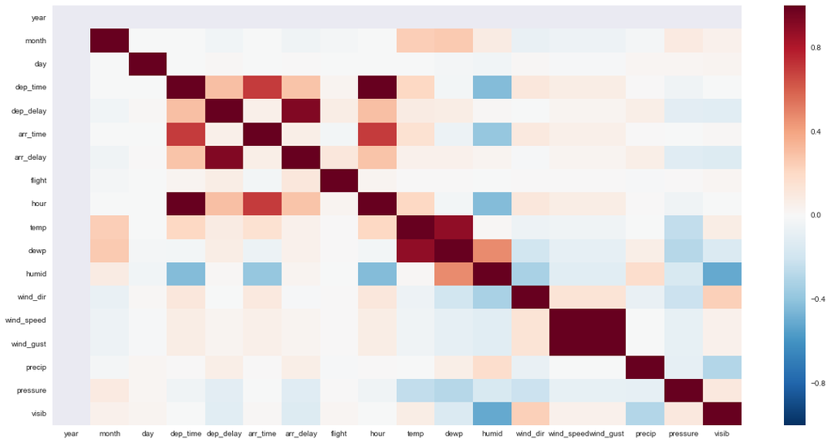

```python
import seaborn as sns

plt.figure(figsize=(20,10))
#Plotting a heatmap which represents the correlation matrix
sns.heatmap(corr,
            xticklabels=corr.columns.values,
            yticklabels=corr.columns.values)
```

A heatmap is plotted to get a better understanding of how the different variables in the flights_weather dataframe are correlated. We can see that overall the departure delay is not highly correlated with nay of the weather conditions. It has a small positive association with temperature and dewpoint and small negative association with pressure and visibility but the correlations are not strong.

We further visualize to see individual patterns of the different weather conditions with departure delay of NYC flights.

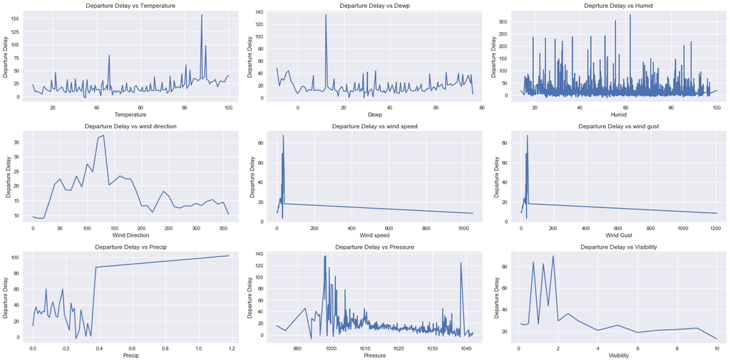

```python
plt.figure(figsize=(20,10))

#Departure delay vs Temperature
plt.subplot(3,3,1)
plt.plot(flights_weather.groupby('temp')['dep_delay'].mean())
plt.title('Departure Delay vs Temperature')
plt.xlabel('Temperature')
plt.ylabel('Departure Delay')

#Departure Delay vs Dewpoint
plt.subplot(3,3,2)
plt.plot(flights_weather.groupby('dewp')['dep_delay'].mean())
plt.title('Departure Delay vs Dewp')
plt.xlabel('Dewp')
plt.ylabel('Departure Delay')

#Departure Delay vs Humid
plt.subplot(3,3,3)
plt.plot(flights_weather.groupby('humid')['dep_delay'].mean())
plt.title('Deprture Delay vs Humid')
plt.xlabel('Humid')
plt.ylabel('Departure Delay')

#Departure Delay vs Wind Direction
plt.subplot(3,3,4)
plt.plot(flights_weather.groupby('wind_dir')['dep_delay'].mean())
plt.title("Departure Delay vs wind direction")
plt.xlabel("Wind Direction")
plt.ylabel("Departure Delay")

#Departure Delay vs Wind Speed
plt.subplot(3,3,5)
plt.plot(flights_weather.groupby('wind_speed')['dep_delay'].mean())
plt.title("Departure Delay vs wind speed")
plt.xlabel("Wind speed")
plt.ylabel("Departure Delay")

#Departure Delay vs Wind Gust
plt.subplot(3,3,6)
plt.plot(flights_weather.groupby('wind_gust')['dep_delay'].mean())
plt.title("Departure Delay vs wind gust")
plt.xlabel("Wind Gust")
plt.ylabel("Departure Delay")

#Departure Delay vs Precipitation
plt.subplot(3,3,7)
plt.plot(flights_weather.groupby('precip')['dep_delay'].mean())
plt.title("Departure Delay vs Precip")
plt.xlabel("Precip")
plt.ylabel("Departure Delay")

#Departure Delay vs Pressure
plt.subplot(3,3,8)
plt.plot(flights_weather.groupby('pressure')['dep_delay'].mean())
plt.title("Departure Delay vs Pressure")
plt.xlabel("Pressure")
plt.ylabel("Departure Delay")

#Departure Delay vs Visibility
plt.subplot(3,3,9)
plt.plot(flights_weather.groupby('visib')['dep_delay'].mean())
plt.title("Departure Delay vs Visibility")
plt.xlabel("Visibility")
plt.ylabel("Departure Delay")

#Straightening out the layout
plt.tight_layout()
```